# RAM: Spatial Origins and Cross-Kingdom Congruence in Bacterial and Fungal Communities - Storyline 3

Residualized regressions: does fungal community structure bacterial?

Kelli Feeser

2026-02-12

[Back to Home](https://kellifeeser.github.io/ksu-paired-amplicon-workflow/index.html)

Document last updated: 2026-02-12

```r
# prettylm() — one-call, readable lm summary

prettylm <- function(mod, digits = 3) {
  stopifnot(inherits(mod, "lm"))

  sm <- summary(mod)

  ## ---- model call ----
  cat("\n\nModel:\n")
  print(mod$call)
  cat("\n")

  ## ---- overall model fit (matches bottom of summary.lm) ----
  fstat <- sm$fstatistic

  overall <- data.frame(
    `Residual SE` = round(sm$sigma, digits),
    `R-squared` = round(sm$r.squared, digits),
    `Adj. R-squared` = round(sm$adj.r.squared, digits),
    `F-statistic` = round(unname(fstat[1]), 2),
    `df` = paste(fstat[2], fstat[3], sep = ", "),
    `p-value` = signif(
      pf(fstat[1], fstat[2], fstat[3], lower.tail = FALSE),
      digits
    )
  )

  cat("Overall model fit:\n")
  print(overall, row.names = FALSE)
  cat("\n")

  ## ---- numeric predictor coefficients only ----
  ## identify numeric predictors from original model frame
  mf <- model.frame(mod)
  response <- all.vars(formula(mod))[1]
  num_vars <- names(Filter(is.numeric, mf))
  num_vars <- setdiff(num_vars, response)

  coef_tab <- sm$coefficients[
    rownames(sm$coefficients) %in% num_vars,
    , drop = FALSE
  ]

  if (nrow(coef_tab) > 0) {
    coef_tab <- as.data.frame(coef_tab)
    coef_tab$Predictor <- rownames(coef_tab)
    rownames(coef_tab) <- NULL

    ## round for presentation
    coef_tab[, c("Estimate", "Std. Error", "t value", "Pr(>|t|)")] <-
      round(coef_tab[, c("Estimate", "Std. Error", "t value", "Pr(>|t|)")],
            digits)

    cat("Numeric predictor coefficients:\n")
    print(coef_tab, row.names = FALSE)
  } else {
    cat("No numeric predictors in model.\n")
  }

  ## invisibly return components in case you want them later
  invisible(
    list(
      model_call = mod$call,
      overall = overall,
      numeric_coefficients = coef_tab
    )
  )
}

# Usage
# prettylm(mod)
```

# 1 Methods

All analyses were conducted in R (version 4.4.3), using the packages betapart 1.6.1, vegan 2.7-2, emmeans 2.0.1, dplyr 1.1.4, and tidyr 1.3.2.

**Sample-level beta-diversity**

Pairwise beta-diversity was calculated separately for fungal and bacterial communities using presence–absence data. Sørensen dissimilarity (βsor) and its turnover (βsim) and nestedness-resultant (βsne) components were computed for each dataset using pairwise decomposition. All beta-diversity metrics were defined at the sample level, with each observation representing a comparison between two samples.

**Pairwise predictors**

Sample-level attributes were assigned to both members of each sample pair, including fungal state, site identity, and vegetation attributes. Fungal state was represented in two ways: (i) symmetric fungal state pairings, encoding unordered combinations of state membership, and (ii) directional state contrasts, encoding ordered transitions between fungal states (for example, F1→F3 versus F3→F1). Site identity and vegetation predictors were defined as pairwise attributes for each comparison.

**Site-level bacterial species pools**

Regional bacterial species pools were defined at the site level as the set of taxa observed across all bacterial communities sampled within a site. A taxon was recorded as present at a site if it was detected in at least one sample from that site. Bacterial pools therefore represent the observed bacterial inventory at each site, independent of host identity. Individual bacterial communities were treated as realizations of this site-level inventory. Additional details, including the leave-one-out implementation and statistical considerations for pairwise data, are provided in the Supplementary Methods.

**Site-level pool realization metrics**

To quantify deviation of individual bacterial communities from the site-level species pool, Sørensen dissimilarity (βsor) and its turnover (βsim) and nestedness-resultant (βsne) components were calculated using pairwise decomposition. Deviation from the pool was quantified by comparing each community to the site-level species pool while excluding the focal community from the pool definition. Pool realization metrics were incorporated into pairwise analyses by assigning each community’s βsor, βsim, and βsne values to sample pairs and representing contrasts as absolute differences between paired communities.

**Fungal community dispersion**

Variation in fungal community dispersion was quantified using distance-to-centroid measures derived from fungal beta-diversity. Dispersion was computed at the sample level, and absolute differences in dispersion between paired samples were used as predictors capturing differences in within-state fungal heterogeneity.

**Statistical analyses and model structure**

Linear models were fitted with bacterial beta-diversity components as response variables. For each bacterial response (βsor, βsim, βsne), baseline models included fungal compositional dissimilarity, a matched bacterial pool realization contrast, fungal dispersion differences, and host-pair identity. Analyses were conducted at the level of pairwise sample comparisons, with site-level quantities treated as contextual attributes rather than independent response variables.

To evaluate correspondence between fungal and bacterial beta-diversity components, we fit a planned 3×3 set of models in which each bacterial response was modeled separately as a function of each fungal beta-diversity component (βsor, βsim, βsne), while holding the remaining baseline predictors constant.

**Residualized state models**

To isolate effects of fungal state independent of compositional, host-associated, and availability-related constraints, bacterial beta-diversity responses were residualized with respect to fungal compositional dissimilarity, bacterial pool realization contrasts, fungal dispersion differences, and host-pair identity. Residuals from these baseline models represent variation in bacterial beta-diversity not attributable to these factors.

Fungal state effects were evaluated by modeling residual bacterial beta-diversity as a function of fungal state, using both symmetric state pairings and directional state contrasts. Residual-model R² was used to quantify the fraction of remaining variance attributable to fungal state. For completeness, we also fit full models including fungal state directly alongside all baseline predictors to confirm consistency with residualized analyses and to compare symmetric and directional representations of fungal state.

**Directional state contrasts**

Directional hypotheses were evaluated by comparing models parameterized with directional state contrasts to models using symmetric state pairings. Directional contrasts among fungal state transitions (for example, F1→F3 versus F3→F1) were estimated from fitted models.

## 1.1 Supplementary Methods

**Construction of site-level species pools and leave-one-out implementation**

Site-level bacterial species pools were defined as the union of taxa observed across all samples collected within a site. To quantify deviation of individual bacterial communities from this inventory without trivial self-inclusion, pool comparisons were implemented using a leave-one-out formulation in which the focal community was excluded from the pool definition prior to calculating beta-diversity components. This approach ensures that pool deviation reflects differences relative to taxa observed elsewhere within the site rather than inclusion of the focal sample in its own reference set.

**Pool realization contrasts**

Pool realization metrics were derived for each community using pairwise beta-diversity decomposition and subsequently incorporated into pairwise analyses as absolute differences between samples. Pool contrasts were matched to the bacterial response component under analysis (βsor, βsim, or βsne). These contrasts encode asymmetry in realization of the locally observed site-level inventory and were treated as constraints rather than focal predictors.

**Fungal dispersion metrics**

Fungal community dispersion was quantified using multivariate dispersion analysis implemented in vegan. Distance-to-centroid values were computed for each fungal community based on fungal beta-diversity, and absolute differences in dispersion between paired samples were used as predictors capturing differences in within-state fungal variability.

**Statistical considerations for pairwise data**

All models were fitted to pairwise sample comparisons, which are not statistically independent due to shared samples across comparisons. Accordingly, inference focused on effect sizes, including baseline model R² and residual-model R² for fungal state effects. Nominal p-values from linear models were not used as primary evidence of effect strength. Dependence-aware approaches, such as permutation at the sample level or clustered variance estimation, would be required for formal hypothesis testing of pairwise effects.

# 2 Code

```r
###############################################################################
# PAIRWISE BETA-DIVERSITY PIPELINE — DESIGN INVARIANTS
#
# This pipeline analyzes pairwise beta-diversity (betapart) at the SAMPLE level
# with SITE-level pool attributes and DIRECTIONAL predictors.
#
# -----------------------------
# CORE DESIGN DECISIONS
# -----------------------------
#
# 1. Beta-diversity distances (β_sor, β_sim, β_sne) are SYMMETRIC by definition.
#    - d(A, B) == d(B, A)
#    - Distances NEVER encode directionality.
#
# 2. Directionality (A → B vs B → A) is encoded ONLY in PREDICTORS,
#    not in distances and not in row identity.
#
# 3. Statistical inference (lm, MRM, Mantel-style models) is done on
#    UNIQUE UNORDERED DYADS (one triangle).
#    - This avoids pseudo-replication and inflated degrees of freedom.
#
# 4. Directional hypotheses (e.g. Fungal cluster F1 → F3 vs F3 → F1)
#    are tested by:
#      - directional predictor variables (e.g. "F1_F3")
#      - model comparison or paired contrasts
#
# 5. Site-level pool beta-diversity is:
#    - symmetric
#    - defined on UNORDERED site pairs
#    - treated as an ATTRIBUTE of sample–sample pairs
#
# 6. X16S_ID != SampleID.
#    - Bacterial beta-diversity is ALWAYS mapped to SampleID
#      before merging with fungal data or metadata.
#
# -----------------------------
# CONSEQUENCES
# -----------------------------
#
# - NO full N × N expansions unless strictly necessary.
# - NO ordering (pmin/pmax) on identity columns (Sample1, Sample2).
# - ALL ordering is explicit and used ONLY for lookup keys.
#
# If any of these assumptions are violated, STOP and refactor —
# do not patch downstream.
##############################################################################
```

```r
# INVARIANTS USED THROUGHOUT THIS PIPELINE
#
# 1. Beta-diversity distances are SYMMETRIC.
#    -> Distances are never directional.
#
# 2. Directionality (A→B vs B→A) lives ONLY in predictors
#    (e.g. fungal cluster transitions).
#
# 3. Statistical inference is done on UNIQUE UNORDERED DYADS
#    (one triangle), unless explicitly stated otherwise.
#
# 4. Directional predictors are tested by paired contrasts
#    or by models that compare A→B vs B→A within the same dyad.
#
# 5. X16S_ID != SampleID, so bacterial data are mapped BEFORE joining.
```

```r
# Load all relevant dissimilarity matrices
fun_beta_sor <- betapart_results[["Fun"]][["all"]][["pairwise"]]$beta.sor
fun_beta_sim <- betapart_results[["Fun"]][["all"]][["pairwise"]]$beta.sim
fun_beta_sne <- betapart_results[["Fun"]][["all"]][["pairwise"]]$beta.sne

bac_beta_sor <- betapart_results[["Bac"]][["all"]][["pairwise"]]$beta.sor
bac_beta_sim <- betapart_results[["Bac"]][["all"]][["pairwise"]]$beta.sim
bac_beta_sne <- betapart_results[["Bac"]][["all"]][["pairwise"]]$beta.sne
```

```r
# Convert fungal beta matrices to long form
# Keep ONE row per unordered sample pair
# (Var1 < Var2 defines the triangle)

df_fun_beta <- as.data.frame(as.table(as.matrix(fun_beta_sor))) %>%
  dplyr::filter(as.character(Var1) < as.character(Var2)) %>%
  dplyr::rename(
    Sample1 = Var1,
    Sample2 = Var2,
    Fun_beta_sor = Freq
  ) %>%
  dplyr::left_join(
    as.data.frame(as.table(as.matrix(fun_beta_sim))) %>%
      dplyr::filter(as.character(Var1) < as.character(Var2)) %>%
      dplyr::rename(
        Sample1 = Var1,
        Sample2 = Var2,
        Fun_beta_sim = Freq
      ),
    by = c("Sample1", "Sample2")
  ) %>%
  dplyr::left_join(
    as.data.frame(as.table(as.matrix(fun_beta_sne))) %>%
      dplyr::filter(as.character(Var1) < as.character(Var2)) %>%
      dplyr::rename(
        Sample1 = Var1,
        Sample2 = Var2,
        Fun_beta_sne = Freq
      ),
    by = c("Sample1", "Sample2")
  )
```

```r
# map X16S → SampleID first
bac_id_map <- sd %>%
  dplyr::select(SampleID, X16S_ID)

# Helper to convert bacterial matrices into SampleID space
build_bac_beta <- function(bac_mat, value_name, id_map) {
  as.data.frame(as.table(as.matrix(bac_mat))) %>%
    dplyr::filter(as.character(Var1) < as.character(Var2)) %>%
    dplyr::rename(X1 = Var1, X2 = Var2, !!value_name := Freq) %>%
    dplyr::left_join(id_map, by = c("X1" = "X16S_ID")) %>%
    dplyr::rename(Sample1 = SampleID) %>%
    dplyr::left_join(id_map, by = c("X2" = "X16S_ID")) %>%
    dplyr::rename(Sample2 = SampleID) %>%
    dplyr::select(Sample1, Sample2, !!value_name)
}

bac_sor_df <- build_bac_beta(bac_beta_sor, "Bac_beta_sor", bac_id_map)
bac_sim_df <- build_bac_beta(bac_beta_sim, "Bac_beta_sim", bac_id_map)
bac_sne_df <- build_bac_beta(bac_beta_sne, "Bac_beta_sne", bac_id_map)
```

```r
# Merge fungal + bacterial beta (still one triangle)
  # each row = one dyad
  # no duplication
  # still symmetric

df_beta <- df_fun_beta %>%
  dplyr::inner_join(bac_sor_df, by = c("Sample1", "Sample2")) %>%
  dplyr::inner_join(bac_sim_df, by = c("Sample1", "Sample2")) %>%
  dplyr::inner_join(bac_sne_df, by = c("Sample1", "Sample2"))


# Assertion / invariant checks
# A. Sample-level beta invariants
# --- ASSERT: one row per unordered sample dyad ---
stopifnot(
  nrow(df_beta) ==
    n_distinct(
      paste(
        pmin(df_beta$Sample1, df_beta$Sample2),
        pmax(df_beta$Sample1, df_beta$Sample2)
      )
    )
)

# --- ASSERT: no self-pairs ---
stopifnot(
  all(df_beta$Sample1 != df_beta$Sample2)
)

# If this fails, a problem was introduced:
  # both triangles, or
  # self-comparisons
```

```r
# Add sample-level metadata (clusters, site, grass)

df_beta <- df_beta %>%
  dplyr::left_join(
    sd %>% dplyr::select(SampleID, Fun_sor_clusters, Site, Grass),
    by = c("Sample1" = "SampleID")
  ) %>%
  dplyr::rename(
    Clus1 = Fun_sor_clusters,
    Site1 = Site,
    Grass1 = Grass
  ) %>%
  dplyr::left_join(
    sd %>% dplyr::select(SampleID, Fun_sor_clusters, Site, Grass),
    by = c("Sample2" = "SampleID")
  ) %>%
  dplyr::rename(
    Clus2 = Fun_sor_clusters,
    Site2 = Site,
    Grass2 = Grass
  )

# normalize factor handling
df_beta <- df_beta %>%
  mutate(
    Clus1  = as.character(Clus1),
    Clus2  = as.character(Clus2),
    Site1  = as.character(Site1),
    Site2  = as.character(Site2),
    Grass1 = as.character(Grass1),
    Grass2 = as.character(Grass2)
  )
```

```r
# Create directional and symmetric predictors
  # Directionality exists only in Fungal_cluster_dir.
  # Distances remain symmetric.

df_beta <- df_beta %>%
  mutate(
    # Directional fungal cluster transition
    Fungal_cluster_dir = paste(Clus1, Clus2, sep = "_"),

    # Symmetric fungal cluster pair
    Fungal_cluster_sym = paste(
      pmin(as.character(Clus1), as.character(Clus2)),
      pmax(as.character(Clus1), as.character(Clus2)),
      sep = "_"
    ),

    # Symmetric site pair
    Site_pair = paste(
      pmin(Site1, Site2),
      pmax(Site1, Site2),
      sep = "_"
    ),

    # Symmetric grass pair
    Grass_pair = paste(
      pmin(Grass1, Grass2),
      pmax(Grass1, Grass2),
      sep = "_"
    )
  )

# Assertion / invariant checks
# A. Sample-level beta invariants
# --- ASSERT: one row per unordered sample dyad ---
stopifnot(
  nrow(df_beta) ==
    n_distinct(
      paste(
        pmin(df_beta$Sample1, df_beta$Sample2),
        pmax(df_beta$Sample1, df_beta$Sample2)
      )
    )
)

# --- ASSERT: no self-pairs ---
stopifnot(
  all(df_beta$Sample1 != df_beta$Sample2)
)

# If this fails, problem reintroduced:
  # both triangles, or
  # self-comparisons
```

Large abs(βsne₁ − βsne₂): the two communities differ strongly in how incompletely they realize the site-level inventory; bacterial turnover may plausibly arise from asymmetric filtering or establishment limitation.

Large abs(βsim₁ − βsim₂): the two communities differ in the extent of localized or idiosyncratic recruitment within the site context.

Small abs(βsne) and abs(βsim) combined with large bacterial turnover: differences are unlikely to be explained by availability or realization alone, strengthening inference of identity-level fungal effects.

**β_sim (turnover / idiosyncrasy)**

Interpretation

How much does this rhizosphere contain taxa not observed in other samples at the same site?

Mechanistically:

- patchy dispersal
- rare colonists
- stochastic recruitment
- fine-scale microhabitat differentiation

This is not redundancy with dispersion:

- dispersion = spread of samples relative to centroid
- β_sim_LOO = directional deviation of one sample relative to the observed site inventory

If you observe…

**A. abs(βsne<sub>pool1</sub> − βsne<sub>pool2</sub>) is large**

**Interpretation:**

The two communities differ strongly in how completely they realize the site-level inventory

One community is substantially more filtered or dispersal-limited relative to what is locally observed

Differences in bacterial turnover could plausibly arise from asymmetric realization alone

If fungal identity effects persist after controlling for this:

fungal states structure bacterial turnover beyond simple filtering intensity

**B. abs(βsim<sub>pool1</sub> − βsim<sub>pool2</sub>) is large**

**Interpretation:**

- The two communities differ in the extent of localized or idiosyncratic recruitment relative to other communities at the same site
- This captures patchy recruitment or rare taxa within the site context, not external novelty
- If fungal identity effects persist:
  - fungal states influence bacterial assembly in ways not reducible to localized stochasticity or patchiness

**C. Both abs(β<sub>sne</sub>) and abs(β<sub>sim</sub>) are small, but bacterial turnover is large**

**Interpretation:**

- The two communities are similarly constrained by local availability and realization
- Differences in bacterial turnover are unlikely to be explained by pool structure alone
- Strong support for identity-level fungal effects
- This is the strongest case for BFI argument.

**D. Pool-realization terms explain most variation; fungal identity weakens**

**Interpretation:**

- Local availability and realization dominate bacterial assembly
- Fungal identity effects may be secondary or conditional
- This is still biologically interpretable and defensible.

```r
# Add site-level bacterial pool beta

# Convert to long format with site info
bac_df <- as.data.frame(decostand(phylo2vegan_OTU(Bac_wholecommunity), method = "pa"))
bac_df$SampleID <- rownames(bac_df)

bac_df <- left_join(bac_df, as.data.frame(phylo2vegan_sd(Bac_wholecommunity)), by = "SampleID")

sample_meta <- phylo2vegan_sd(Bac_wholecommunity)

bac_otu_df <- as.data.frame(phylo2vegan_OTU(Bac_wholecommunity))
bac_otu_df$SampleID <- as.character(rep(nrow(bac_otu_df)))
bac_otu_df$SampleID <- rownames(bac_otu_df)

bac_otu_df[ , setdiff(names(bac_otu_df), "SampleID")] <- lapply(
  bac_otu_df[ , setdiff(names(bac_otu_df), "SampleID")],
  function(x) as.numeric(x > 0)
)

# Join with full sample metadata
bac_otu_meta <- dplyr::left_join(bac_otu_df, sample_meta, by = "SampleID")


# Identify OTU columns
otu_cols <- bac_otu_meta %>%
  dplyr::select(where(is.numeric)) %>%
  names()


# Function: leave-one-out pool β for one site
# This returns one row per sample with βsor / βsim / βsne
# relative to the site pool excluding that sample.
library(betapart)

compute_site_LOO_pool_beta <- function(df_site, otu_cols) {

  results <- lapply(seq_len(nrow(df_site)), function(i) {

    focal_sample <- df_site$SampleID[i]

    # focal assemblage (force PA, force NA -> 0)
    focal_vec <- as.numeric(df_site[i, otu_cols, drop = TRUE] > 0)
    focal_vec[is.na(focal_vec)] <- 0
    names(focal_vec) <- otu_cols

    # leave-one-out pool (union of others, force PA)
    pool_vec <- as.numeric(
      colSums(df_site[-i, otu_cols, drop = FALSE] > 0, na.rm = TRUE) > 0
    )
    names(pool_vec) <- otu_cols

    # combine into PA matrix
    comp_mat <- rbind(
      SAMPLE = focal_vec,
      POOL   = pool_vec
    )

    comp_mat <- as.data.frame(comp_mat)

    # final guarantee
    stopifnot(
      all(as.vector(as.matrix(comp_mat)) %in% c(0, 1))
    )

    # Sørensen partitioning
    beta <- betapart::beta.pair(
      comp_mat,
      index.family = "sorensen"
    )

    tibble::tibble(
      SampleID = focal_sample,
      Bac_pool_sor_LOO = as.numeric(beta$beta.sor),
      Bac_pool_sim_LOO = as.numeric(beta$beta.sim),
      Bac_pool_sne_LOO = as.numeric(beta$beta.sne)
    )
  })

  dplyr::bind_rows(results)
}




# Apply per site
bac_pool_LOO <- bac_otu_meta %>%
  dplyr::group_by(Site) %>%
  dplyr::group_modify(~ compute_site_LOO_pool_beta(.x, otu_cols)) %>%
  dplyr::ungroup()

# Sanity check:
stopifnot(
  nrow(bac_pool_LOO) == nrow(bac_otu_meta),
  !any(is.na(bac_pool_LOO$Bac_pool_sor_LOO)),
  !any(is.na(bac_pool_LOO$Bac_pool_sim_LOO)),
  !any(is.na(bac_pool_LOO$Bac_pool_sne_LOO))
)

summary(bac_pool_LOO$Bac_pool_sim_LOO)
summary(bac_pool_LOO$Bac_pool_sne_LOO)
summary(bac_pool_LOO$Bac_pool_sor_LOO)


all.equal(
  bac_pool_LOO$Bac_pool_sor_LOO,
  bac_pool_LOO$Bac_pool_sim_LOO + bac_pool_LOO$Bac_pool_sne_LOO
)

stopifnot(
  nrow(bac_pool_LOO) == nrow(bac_otu_meta),
  !any(is.na(bac_pool_LOO))
)

# Expected behavior:
# βsne generally > 0
# βsim often small but non-zero
# βsor = βsim + βsne

# Attach ITS IDs to bac_pool_LOO using X16S_ID
bac_pool_LOO <- bac_pool_LOO %>%
  dplyr::left_join(
    sd %>% dplyr::select(SampleID, X16S_ID),
    by = c("SampleID" = "X16S_ID")
  )

# Attach LOO pool values to pairwise dataframe
df_beta_pool <- df_beta %>%
  dplyr::left_join(
    bac_pool_LOO,
    by = c("Sample1" = "SampleID.y")
  ) %>%
  dplyr::rename(
    Bac_pool_sor_1 = Bac_pool_sor_LOO,
    Bac_pool_sim_1 = Bac_pool_sim_LOO,
    Bac_pool_sne_1 = Bac_pool_sne_LOO
  ) %>%
  dplyr::left_join(
    bac_pool_LOO,
    by = c("Sample2" = "SampleID.y")
  ) %>%
  dplyr::rename(
    Bac_pool_sor_2 = Bac_pool_sor_LOO,
    Bac_pool_sim_2 = Bac_pool_sim_LOO,
    Bac_pool_sne_2 = Bac_pool_sne_LOO
  )

df_beta_pool <- df_beta_pool %>%
  dplyr::select(
    -Site.x, -Site.y,
    -SampleID.x, -SampleID.y
  )

# Define pairwise pool-realization contrasts (to use in models)
df_beta_pool <- df_beta_pool %>%
  dplyr::mutate(
    Bac_pool_sor_diff = abs(Bac_pool_sor_1 - Bac_pool_sor_2),
    Bac_pool_sim_diff = abs(Bac_pool_sim_1 - Bac_pool_sim_2),
    Bac_pool_sne_diff = abs(Bac_pool_sne_1 - Bac_pool_sne_2)
  )

# Final sanity checks (strongly recommended)
stopifnot(
  !any(is.na(df_beta_pool$Bac_pool_sor_diff)),
  !any(is.na(df_beta_pool$Bac_pool_sim_diff)),
  !any(is.na(df_beta_pool$Bac_pool_sne_diff))
)

saveRDS(df_beta_pool, file = "../processed_data/clean_rds_saves/df_beta_pool.rds")

# df_beta_pool has:
# A site-level availability context, defined as the observed inventory at that site
# A per-sample realization of that context via LOO βsor / βsim / βsne
# A pairwise contrast capturing asymmetry in realization between two samples
# So in regression:
# Bac_pool_sne_diff controls for differences in under-realization / filtering
# Bac_pool_sim_diff controls for differences in localized or idiosyncratic recruitment
```

```r
# 1. Compute fungal beta diversity matrix
# 2. Map sample-to-cluster info
# Ensure you have a vector like:
fun_cluster_vector <- sample_data(Fun_wholecommunity)$Fun_sor_clusters # or use df_beta$Fungal_cluster

# 3. Run betadisper
Fun_sor_clus_disp <- betadisper(fun_beta_sor, group = fun_cluster_vector)

# 4. Test for dispersion differences among fungal clusters
# anova(Fun_sor_clus_disp)

# Extract per-sample distances
df_disp_fun <- data.frame( SampleID = names(Fun_sor_clus_disp$distances), Sample_dispersion = Fun_sor_clus_disp$distances )

# Add fungal dispersion (symmetric)
df_beta_pool_disp <- df_beta_pool %>%
  dplyr::left_join(df_disp_fun, by = c("Sample1" = "SampleID")) %>%
  dplyr::rename(Fun_disp_1 = Sample_dispersion) %>%
  dplyr::left_join(df_disp_fun, by = c("Sample2" = "SampleID")) %>%
  dplyr::rename(Fun_disp_2 = Sample_dispersion) %>%
  mutate(
    Fungal_dispersion_diff = abs(Fun_disp_1 - Fun_disp_2)
  )



# Assertion / invariant checks


# Directional predictor sanity
# --- ASSERT: directional fungal transitions exist ---
stopifnot(
  any(df_beta_pool_disp$Fungal_cluster_dir !=
        paste(df_beta_pool_disp$Clus2, df_beta_pool_disp$Clus1, sep = "_"))
)

# --- ASSERT: symmetric and directional predictors differ ---
stopifnot(
  any(df_beta_pool_disp$Fungal_cluster_dir != df_beta_pool_disp$Fungal_cluster_sym)
)

# If this fails:
# directionality was collapsed somewhere
# or the predictor was built incorrectly


# Optional: one-line “panic button”
  #
  # When debugging:
  # glimpse(df_beta)
  #
  # You should always see:
  # Sample1, Sample2 → identity
  # Fungal_cluster_dir → directional
  # Fungal_cluster_sym → symmetric
  # Site_pair → symmetric lookup
  # Bac_beta_* → responses
  # Bac_pool_* → attributes
  #
  # If any of those roles blur, stop.
stopifnot(
  any(df_beta_pool_disp$Fungal_cluster_dir !=
        paste(df_beta_pool_disp$Clus2, df_beta_pool_disp$Clus1, sep = "_"))
)
# which(names(df_beta_pool_disp) == "")

# directional‐predictor
stopifnot(
  "Fungal_cluster_dir" %in% names(df_beta_pool_disp),
  "Fungal_cluster_sym" %in% names(df_beta_pool_disp),
  "Clus1" %in% names(df_beta_pool_disp),
  "Clus2" %in% names(df_beta_pool_disp)
)
```

# 3 Regressions

```r
# library(dplyr)

# start from joined table (rename if needed)
dat <- df_beta_pool_disp %>%
  mutate(
    across(c(Sample1, Sample2, Site1, Site2, Grass_pair,
             Fungal_cluster_dir, Fungal_cluster_sym), as.character)
  )
```

## 3.1 Collinearity

```r
num_pred <- dat %>%
  select(
    Fun_beta_sor, Fun_beta_sim, Fun_beta_sne,
    Bac_pool_sor_diff, Bac_pool_sim_diff, Bac_pool_sne_diff,
    Fungal_dispersion_diff
  ) %>%
  na.omit()

cor_mat <- cor(num_pred, method = "pearson")
round(cor_mat, 2)
# in the same model, dont have Fun_beta_sim and Fun_beta_sor, Bac_pool_sor_diff and Bac_pool_sne_diff

# VIF
library(car)

vif_screen <- lm(
  Bac_beta_sim ~ Fun_beta_sim + Bac_pool_sim_diff + Fungal_dispersion_diff,
  data = dat
)
car::vif(vif_screen)

vif_screen2 <- lm(
  Bac_beta_sor ~ Fun_beta_sor + Bac_pool_sor_diff + Fungal_dispersion_diff,
  data = dat
)
car::vif(vif_screen2)
```

## 3.2 Summary 3x3 table

- `base_R2` tells you how much is explained by constraints + chosen fungal metric.
- `state_R2` is the identity signal after residualization (directly comparable across the 9 cells).
- `fungal_beta_est/p` describes which fungal component aligns with the bacterial response in the baseline.

Table X. Summary of regression results from the 3×3 cross-component analysis relating bacterial and fungal β-diversity components. Each row corresponds to a bacterial response component (βsor, βsim, βsne), and each column corresponds to a fungal predictor component (βsor, βsim, βsne). For each combination, the baseline model included the fungal β-diversity component, a matched bacterial pool-realization contrast, fungal dispersion differences, and host-pair identity. Residuals from these baseline models were then regressed on fungal state to quantify identity-level effects independent of compositional, availability, dispersion, and host constraints. Reported values include baseline model R², residual-model R² for fungal state (fraction of remaining variance explained by state), and selected coefficient estimates from baseline models. Residual-model R² values are interpreted as measures of association strength rather than formal hypothesis tests due to non-independence of pairwise comparisons. **Residual state R² values are not additive with baseline R² values and represent the proportion of variance remaining after baseline constraints are accounted for.**

Column definitions: Baseline R² and adjusted R² correspond to the baseline constraint model including fungal β-diversity, matched bacterial pool-realization contrasts, fungal dispersion differences, and host-pair identity. Residual state R² corresponds to the R² of the residualized state-only model and represents the fraction of variance remaining after baseline constraints that is attributable to fungal state. Fungal β coefficients and pool contrast coefficients are taken from the baseline models. State F, degrees of freedom (df₁, df₂), and p-values correspond to the overall F-test of the residualized state model and are reported for completeness.

Alt/shorter legend: Table X. Results of the 3×3 cross-component regression analysis relating bacterial (rows) and fungal (columns) β-diversity components. Baseline models included fungal β-diversity, matched bacterial pool-realization contrasts, fungal dispersion differences, and host-pair identity. Residual-model R² values quantify variance in bacterial β-diversity remaining after baseline constraints that is attributable to fungal state.

```r
library(dplyr)
library(broom)

# dat is analysis dataframe with:
# Bac_beta_sor/sim/sne
# Fun_beta_sor/sim/sne
# Bac_pool_sor_diff/sim_diff/sne_diff
# Grass_pair
# Fungal_dispersion_diff
# Fungal_cluster_dir

bac_responses <- c("sor", "sim", "sne")
fun_preds     <- c("sor", "sim", "sne")

out <- list()

for (b in bac_responses) {
  for (f in fun_preds) {

    y <- paste0("Bac_beta_", b)
    x <- paste0("Fun_beta_", f)
    pool <- paste0("Bac_pool_", b, "_diff")

    # baseline constraints model (no state)
    form_base <- as.formula(
      paste(y, "~", x, "+", pool, "+ Fungal_dispersion_diff + Grass_pair")
    )

    m_base <- lm(form_base, data = dat)

    # residuals for state test
    dat_sub <- dat %>%
      filter(complete.cases(.[, all.vars(form_base)])) %>%
      mutate(resid_y = resid(m_base))

    # state test on residuals (directional)
    m_state <- lm(resid_y ~ Fungal_cluster_dir, data = dat_sub)

    out[[paste(b, f, sep = "_")]] <- tibble(
      Bac_response = b,
      Fun_predictor = f,

      n = nrow(dat_sub),

      base_R2 = summary(m_base)$r.squared,
      base_adjR2 = summary(m_base)$adj.r.squared,

      # incremental variance explained by state on residuals
      state_R2 = summary(m_state)$r.squared,

      # overall significance of state term
      state_F = unname(summary(m_state)$fstatistic["value"]),
      state_df1 = unname(summary(m_state)$fstatistic["numdf"]),
      state_df2 = unname(summary(m_state)$fstatistic["dendf"]),
      state_p = pf(
        summary(m_state)$fstatistic["value"],
        summary(m_state)$fstatistic["numdf"],
        summary(m_state)$fstatistic["dendf"],
        lower.tail = FALSE
      ),

      # fungal beta coefficient in baseline model (effect direction/magnitude)
      fungal_beta_est = coef(summary(m_base))[x, "Estimate"],
      fungal_beta_p   = coef(summary(m_base))[x, "Pr(>|t|)"],

      pool_est = coef(summary(m_base))[pool, "Estimate"],
      pool_p   = coef(summary(m_base))[pool, "Pr(>|t|)"]
    )
  }
}

grid_results <- bind_rows(out) %>%
  arrange(
    factor(Bac_response, levels = c("sor", "sim", "sne")),
    factor(Fun_predictor, levels = c("sor", "sim", "sne"))
  )

# grid_results
```

```r
library(knitr)
library(kableExtra)

grid_results %>%
  kable(col.names = c(
      "Bacterial β",
      "Fungal β",
      "n",
      "Baseline R²",
      "Baseline adj. R²",
      "Residual state R²",
      "State F",
      "df₁",
      "df₂",
      "State p",
      "Fungal β coef.",
      "Fungal β p",
      "Pool coef.",
      "Pool p"
    ),
    digits = 3,
    caption = "Summary of 3×3 cross-component regression results"
  ) %>%
  scroll_box(width = "100%", height = "300px")
```

Summary of 3×3 cross-component regression results

| Bacterial β | Fungal β | n | Baseline R² | Baseline adj. R² | Residual state R² | State F | df₁ | df₂ | State p | Fungal β coef. | Fungal β p | Pool coef. | Pool p |
| --- | --- | --- | --- | --- | --- | --- | --- | --- | --- | --- | --- | --- | --- |
| sor | sor | 57173 | 0.220 | 0.220 | 0.257 | 203.519 | 97 | 57075 | 0 | 0.038 | 0 | 0.265 | 0.000 |
| sor | sim | 57173 | 0.221 | 0.220 | 0.258 | 204.562 | 97 | 57075 | 0 | 0.036 | 0 | 0.265 | 0.000 |
| sor | sne | 57173 | 0.217 | 0.217 | 0.246 | 192.191 | 97 | 57075 | 0 | -0.060 | 0 | 0.271 | 0.000 |
| sim | sor | 57173 | 0.143 | 0.142 | 0.211 | 157.246 | 97 | 57075 | 0 | 0.016 | 0 | -0.003 | 0.710 |
| sim | sim | 57173 | 0.143 | 0.143 | 0.214 | 159.953 | 97 | 57075 | 0 | 0.021 | 0 | -0.008 | 0.391 |
| sim | sne | 57173 | 0.145 | 0.144 | 0.210 | 156.874 | 97 | 57075 | 0 | -0.143 | 0 | -0.002 | 0.827 |
| sne | sor | 57173 | 0.061 | 0.061 | 0.137 | 93.607 | 97 | 57075 | 0 | 0.024 | 0 | 0.086 | 0.000 |
| sne | sim | 57173 | 0.060 | 0.059 | 0.139 | 94.853 | 97 | 57075 | 0 | 0.017 | 0 | 0.088 | 0.000 |
| sne | sne | 57173 | 0.060 | 0.060 | 0.145 | 99.772 | 97 | 57075 | 0 | 0.086 | 0 | 0.092 | 0.000 |

**Column Names**

Baseline R² / adj. R² - R² of the baseline constraint model (no state)

Residual state R² - R² from the residualized state-only model - fraction of variance remaining after constraints explained by fungal state

Fungal β coefficient (fungal_beta_est) - coefficient of the fungal β-diversity predictor in the baseline model

Pool contrast coefficient (Pool contrast coefficient) - coefficient of the matched bacterial pool-realization contrast in the baseline model

State F / df / p - overall F-test for the residualized state model - reported for completeness, not primary inference

## 3.3 Baseline constraint models (no residuals)

Model Roles:

- **Full models** = secondary confirmation and directionality check
- Residualized models = primary inference for magnitude of state effect (next section)

### 3.3.1 Fun_sor

**Fungal total dissimilarity**

This establishes whether:  
- fungal total dissimilarity alone matters,  
- pool constraint adds explanatory power,  
- dispersion adds explanatory power beyond those

Stepwise build-up:

#### 3.3.1.1 Stepwise (1-3): y = F<sub>diss</sub>+pool+F<sub>disp</sub>

Response: Bac_beta_sor  
Predictors: Fun_beta_sor, Bac_pool_sor_diff, Fungal_dispersion_diff

```r
m0_Bsor_Fsor <- lm(
  Bac_beta_sor ~ Fun_beta_sor,
  data = dat
)

m1_Bsor_Fsor <- lm(
  Bac_beta_sor ~ Fun_beta_sor + Bac_pool_sor_diff,
  data = dat
)

m2_Bsor_Fsor <- lm(
  Bac_beta_sor ~ Fun_beta_sor + Bac_pool_sor_diff + Fungal_dispersion_diff,
  data = dat
)


# summary(m0_sor)

anova(m0_Bsor_Fsor, m1_Bsor_Fsor, m2_Bsor_Fsor)  # nested comparison
```

```
## Analysis of Variance Table
##
## Model 1: Bac_beta_sor ~ Fun_beta_sor
## Model 2: Bac_beta_sor ~ Fun_beta_sor + Bac_pool_sor_diff
## Model 3: Bac_beta_sor ~ Fun_beta_sor + Bac_pool_sor_diff + Fungal_dispersion_diff
##   Res.Df    RSS Df Sum of Sq       F    Pr(>F)
## 1  57171 392.67
## 2  57170 379.75  1   12.9216 1952.54 < 2.2e-16 ***
## 3  57169 378.34  1    1.4157  213.91 < 2.2e-16 ***
## ---
## Signif. codes:  0 '***' 0.001 '**' 0.01 '*' 0.05 '.' 0.1 ' ' 1
```

```r
cat("\n\n--- Model Summary ---\n")
```

```
##
##
## --- Model Summary ---
```

```r
summary(m2_Bsor_Fsor)
```

```
##
## Call:
## lm(formula = Bac_beta_sor ~ Fun_beta_sor + Bac_pool_sor_diff +
##     Fungal_dispersion_diff, data = dat)
##
## Residuals:
##       Min        1Q    Median        3Q       Max
## -0.246637 -0.058635 -0.002682  0.054746  0.242113
##
## Coefficients:
##                        Estimate Std. Error t value Pr(>|t|)
## (Intercept)            0.630545   0.002021  311.97   <2e-16 ***
## Fun_beta_sor           0.041675   0.002474   16.85   <2e-16 ***
## Bac_pool_sor_diff      0.258494   0.005805   44.53   <2e-16 ***
## Fungal_dispersion_diff 0.060403   0.004130   14.63   <2e-16 ***
## ---
## Signif. codes:  0 '***' 0.001 '**' 0.01 '*' 0.05 '.' 0.1 ' ' 1
##
## Residual standard error: 0.08135 on 57169 degrees of freedom
## Multiple R-squared:  0.04571,    Adjusted R-squared:  0.04566
## F-statistic: 912.8 on 3 and 57169 DF,  p-value: < 2.2e-16
```

#### 3.3.1.2 Baseline: F<sub>diss</sub>+pool+F<sub>disp</sub>+Host

**Adding Grass_pair**

```r
base_Bsor_Fsor <- lm(
  Bac_beta_sor ~ Fun_beta_sor + Bac_pool_sor_diff +
    Fungal_dispersion_diff + Grass_pair,
  data = dat
)

anova(m2_Bsor_Fsor, base_Bsor_Fsor)
```

```
## Analysis of Variance Table
##
## Model 1: Bac_beta_sor ~ Fun_beta_sor + Bac_pool_sor_diff + Fungal_dispersion_diff
## Model 2: Bac_beta_sor ~ Fun_beta_sor + Bac_pool_sor_diff + Fungal_dispersion_diff +
##     Grass_pair
##   Res.Df    RSS Df Sum of Sq      F    Pr(>F)
## 1  57169 378.34
## 2  57155 309.09 14    69.249 914.66 < 2.2e-16 ***
## ---
## Signif. codes:  0 '***' 0.001 '**' 0.01 '*' 0.05 '.' 0.1 ' ' 1
```

```r
cat("\n\n--- Model Summary ---\n")
```

```
##
##
## --- Model Summary ---
```

```r
summary(base_Bsor_Fsor)
```

```
##
## Call:
## lm(formula = Bac_beta_sor ~ Fun_beta_sor + Bac_pool_sor_diff +
##     Fungal_dispersion_diff + Grass_pair, data = dat)
##
## Residuals:
##       Min        1Q    Median        3Q       Max
## -0.244962 -0.051161 -0.002931  0.049054  0.225519
##
## Coefficients:
##                          Estimate Std. Error t value Pr(>|t|)
## (Intercept)             0.6319473  0.0023741 266.183  < 2e-16 ***
## Fun_beta_sor            0.0379558  0.0022600  16.795  < 2e-16 ***
## Bac_pool_sor_diff       0.2648892  0.0052790  50.177  < 2e-16 ***
## Fungal_dispersion_diff  0.0665643  0.0037651  17.679  < 2e-16 ***
## Grass_pairANGE_BOER     0.0686117  0.0019708  34.814  < 2e-16 ***
## Grass_pairANGE_BOGR     0.0235607  0.0019715  11.950  < 2e-16 ***
## Grass_pairANGE_BUDA     0.0065308  0.0019985   3.268  0.00108 **
## Grass_pairANGE_SCSC     0.0046561  0.0017915   2.599  0.00935 **
## Grass_pairBOER_BOER    -0.0561413  0.0024872 -22.572  < 2e-16 ***
## Grass_pairBOER_BOGR    -0.0344019  0.0020826 -16.519  < 2e-16 ***
## Grass_pairBOER_BUDA    -0.0121277  0.0020582  -5.892 3.83e-09 ***
## Grass_pairBOER_SCSC     0.0464539  0.0018192  25.536  < 2e-16 ***
## Grass_pairBOGR_BOGR    -0.0621425  0.0024206 -25.672  < 2e-16 ***
## Grass_pairBOGR_BUDA    -0.0554360  0.0020848 -26.591  < 2e-16 ***
## Grass_pairBOGR_SCSC    -0.0002918  0.0018555  -0.157  0.87503
## Grass_pairBUDA_BUDA    -0.0923441  0.0025707 -35.922  < 2e-16 ***
## Grass_pairBUDA_SCSC    -0.0107417  0.0018257  -5.883 4.04e-09 ***
## Grass_pairSCSC_SCSC    -0.0020311  0.0018563  -1.094  0.27389
## ---
## Signif. codes:  0 '***' 0.001 '**' 0.01 '*' 0.05 '.' 0.1 ' ' 1
##
## Residual standard error: 0.07354 on 57155 degrees of freedom
## Multiple R-squared:  0.2204, Adjusted R-squared:  0.2201
## F-statistic: 950.4 on 17 and 57155 DF,  p-value: < 2.2e-16
```

#### 3.3.1.3 Full models: F<sub>diss</sub>+pool+F<sub>disp</sub>+Host+F<sub>state</sub>

**Full models: Adding Fungal state identity (no residuals)**

These are full models where:

1. fungal compositional dissorilarity,
2. pool-realization contrast,
3. fungal dispersion,
4. host pairing,

are treated as covariates sorultaneously, and (v) fungal state is added as an additional predictor (with directional and symmetric variations).

They test whether fungal state explains additional variation when included directly alongside all other covariates.

Purpose:

- show consistency
- demonstrate that state is not an artifact of residualization
- confirm directionality vs symmetry via AIC

But they are not ideal for quantifying state effect size, because variance attribution is shared among correlated predictors (see residualized models).

```r
m4_Bsor_Fsor_sym <- lm(
  Bac_beta_sor ~ Fun_beta_sor + Bac_pool_sor_diff + Fungal_dispersion_diff + Grass_pair +
    Fungal_cluster_sym,
  data = dat
)

m4_Bsor_Fsor_dir <- lm(
  Bac_beta_sor ~ Fun_beta_sor + Bac_pool_sor_diff + Fungal_dispersion_diff + Grass_pair +
    Fungal_cluster_dir,
  data = dat
)

#
m4_Bsim_Fsor_sym <- lm(
  Bac_beta_sim ~ Fun_beta_sor + Bac_pool_sor_diff + Fungal_dispersion_diff + Grass_pair +
    Fungal_cluster_sym,
  data = dat
)


m4_Bsim_Fsor_dir <- lm(
  Bac_beta_sim ~ Fun_beta_sor + Bac_pool_sor_diff + Fungal_dispersion_diff + Grass_pair +
    Fungal_cluster_dir,
  data = dat
)

#
m4_Bsne_Fsor_sym <- lm(
  Bac_beta_sne ~ Fun_beta_sor + Bac_pool_sor_diff + Fungal_dispersion_diff + Grass_pair +
    Fungal_cluster_sym,
  data = dat
)

m4_Bsne_Fsor_dir <- lm(
  Bac_beta_sne ~ Fun_beta_sor + Bac_pool_sor_diff + Fungal_dispersion_diff + Grass_pair +
    Fungal_cluster_dir,
  data = dat
)

cat("\n\n--- ANOVA ~ Full Model Symmetric ---\n")
anova(base_Bsor_Fsor, m4_Bsor_Fsor_sym)
cat("\n\n--- ANOVA ~ Full Model Directional ---\n")
anova(base_Bsor_Fsor, m4_Bsor_Fsor_dir)

cat("\n\n--- AIC ---\n")
AIC(base_Bsor_Fsor, m4_Bsor_Fsor_sym, m4_Bsor_Fsor_dir)
cat("\n\n--- Model Summary ---\n")
summary(m4_Bsor_Fsor_dir)
```

```
##
##
## --- ANOVA ~ Full Model Symmetric ---
## Analysis of Variance Table
##
## Model 1: Bac_beta_sor ~ Fun_beta_sor + Bac_pool_sor_diff + Fungal_dispersion_diff +
##     Grass_pair
## Model 2: Bac_beta_sor ~ Fun_beta_sor + Bac_pool_sor_diff + Fungal_dispersion_diff +
##     Grass_pair + Fungal_cluster_sym
##   Res.Df    RSS Df Sum of Sq      F    Pr(>F)
## 1  57155 309.09
## 2  57101 205.67 54    103.41 531.69 < 2.2e-16 ***
## ---
## Signif. codes:  0 '***' 0.001 '**' 0.01 '*' 0.05 '.' 0.1 ' ' 1
##
##
## --- ANOVA ~ Full Model Directional ---
## Analysis of Variance Table
##
## Model 1: Bac_beta_sor ~ Fun_beta_sor + Bac_pool_sor_diff + Fungal_dispersion_diff +
##     Grass_pair
## Model 2: Bac_beta_sor ~ Fun_beta_sor + Bac_pool_sor_diff + Fungal_dispersion_diff +
##     Grass_pair + Fungal_cluster_dir
##   Res.Df    RSS Df Sum of Sq      F    Pr(>F)
## 1  57155 309.09
## 2  57058 197.95 97    111.14 330.25 < 2.2e-16 ***
## ---
## Signif. codes:  0 '***' 0.001 '**' 0.01 '*' 0.05 '.' 0.1 ' ' 1
##
##
## --- AIC ---
##                   df       AIC
## base_Bsor_Fsor    19 -136167.5
## m4_Bsor_Fsor_sym  73 -159348.2
## m4_Bsor_Fsor_dir 116 -161450.0
##
##
## --- Model Summary ---
##
## Call:
```

[output cut: 116 more lines]

```
## Fungal_cluster_dirF9_F10  -0.249538   0.003491 -71.478  < 2e-16 ***
## Fungal_cluster_dirF9_F2   -0.238773   0.005615 -42.527  < 2e-16 ***
## Fungal_cluster_dirF9_F3   -0.162197   0.003198 -50.722  < 2e-16 ***
## Fungal_cluster_dirF9_F4   -0.244071   0.003155 -77.355  < 2e-16 ***
## Fungal_cluster_dirF9_F5   -0.179508   0.003457 -51.932  < 2e-16 ***
## Fungal_cluster_dirF9_F6   -0.215885   0.004415 -48.901  < 2e-16 ***
## Fungal_cluster_dirF9_F7   -0.228053   0.003263 -69.884  < 2e-16 ***
## Fungal_cluster_dirF9_F8   -0.283094   0.002846 -99.466  < 2e-16 ***
## Fungal_cluster_dirF9_F9   -0.232825   0.002976 -78.245  < 2e-16 ***
## ---
## Signif. codes:  0 '***' 0.001 '**' 0.01 '*' 0.05 '.' 0.1 ' ' 1
##
## Residual standard error: 0.0589 on 57058 degrees of freedom
## Multiple R-squared:  0.5007, Adjusted R-squared:  0.4997
## F-statistic: 501.9 on 114 and 57058 DF,  p-value: < 2.2e-16
```

##### 3.3.1.3.1 Bac_sor ~ Fun_sor

```r
summary(m4_Bsor_Fsor_dir)
```

```
##
## Call:
## lm(formula = Bac_beta_sor ~ Fun_beta_sor + Bac_pool_sor_diff +
##     Fungal_dispersion_diff + Grass_pair + Fungal_cluster_dir,
##     data = dat)
##
## Residuals:
##       Min        1Q    Median        3Q       Max
## -0.277918 -0.038435 -0.001082  0.037035  0.221844
##
## Coefficients:
##                            Estimate Std. Error t value Pr(>|t|)
## (Intercept)                0.446271   0.003041 146.740  < 2e-16 ***
## Fun_beta_sor               0.517296   0.005392  95.942  < 2e-16 ***
## Bac_pool_sor_diff          0.131160   0.004703  27.889  < 2e-16 ***
## Fungal_dispersion_diff    -0.001942   0.003932  -0.494    0.621
## Grass_pairANGE_BOER        0.046610   0.001745  26.714  < 2e-16 ***
## Grass_pairANGE_BOGR        0.016305   0.001690   9.648  < 2e-16 ***
## Grass_pairANGE_BUDA       -0.011629   0.001677  -6.933 4.18e-12 ***
## Grass_pairANGE_SCSC       -0.006129   0.001459  -4.202 2.65e-05 ***
## Grass_pairBOER_BOER       -0.068512   0.002443 -28.044  < 2e-16 ***
## Grass_pairBOER_BOGR       -0.045667   0.001892 -24.140  < 2e-16 ***
## Grass_pairBOER_BUDA       -0.038342   0.001889 -20.302  < 2e-16 ***
## Grass_pairBOER_SCSC        0.020512   0.001662  12.339  < 2e-16 ***
## Grass_pairBOGR_BOGR       -0.065006   0.002083 -31.203  < 2e-16 ***
## Grass_pairBOGR_BUDA       -0.059135   0.001839 -32.152  < 2e-16 ***
## Grass_pairBOGR_SCSC       -0.009184   0.001616  -5.685 1.31e-08 ***
## Grass_pairBUDA_BUDA       -0.105221   0.002211 -47.598  < 2e-16 ***
## Grass_pairBUDA_SCSC       -0.033423   0.001570 -21.285  < 2e-16 ***
## Grass_pairSCSC_SCSC       -0.019502   0.001543 -12.639  < 2e-16 ***
## Fungal_cluster_dirF1_F10  -0.181146   0.004022 -45.040  < 2e-16 ***
## Fungal_cluster_dirF1_F2   -0.193327   0.003330 -58.064  < 2e-16 ***
## Fungal_cluster_dirF1_F3   -0.136574   0.011532 -11.843  < 2e-16 ***
## Fungal_cluster_dirF1_F4   -0.207064   0.003316 -62.450  < 2e-16 ***
## Fungal_cluster_dirF1_F5   -0.218571   0.003374 -64.780  < 2e-16 ***
## Fungal_cluster_dirF1_F6   -0.218771   0.003691 -59.279  < 2e-16 ***
## Fungal_cluster_dirF1_F7   -0.218836   0.002914 -75.092  < 2e-16 ***
## Fungal_cluster_dirF1_F8   -0.240205   0.002649 -90.683  < 2e-16 ***
## Fungal_cluster_dirF1_F9   -0.214335   0.002735 -78.374  < 2e-16 ***
## Fungal_cluster_dirF10_F1  -0.186800   0.002543 -73.456  < 2e-16 ***
```

[output cut: 78 more lines]

```
## Fungal_cluster_dirF9_F10  -0.249538   0.003491 -71.478  < 2e-16 ***
## Fungal_cluster_dirF9_F2   -0.238773   0.005615 -42.527  < 2e-16 ***
## Fungal_cluster_dirF9_F3   -0.162197   0.003198 -50.722  < 2e-16 ***
## Fungal_cluster_dirF9_F4   -0.244071   0.003155 -77.355  < 2e-16 ***
## Fungal_cluster_dirF9_F5   -0.179508   0.003457 -51.932  < 2e-16 ***
## Fungal_cluster_dirF9_F6   -0.215885   0.004415 -48.901  < 2e-16 ***
## Fungal_cluster_dirF9_F7   -0.228053   0.003263 -69.884  < 2e-16 ***
## Fungal_cluster_dirF9_F8   -0.283094   0.002846 -99.466  < 2e-16 ***
## Fungal_cluster_dirF9_F9   -0.232825   0.002976 -78.245  < 2e-16 ***
## ---
## Signif. codes:  0 '***' 0.001 '**' 0.01 '*' 0.05 '.' 0.1 ' ' 1
##
## Residual standard error: 0.0589 on 57058 degrees of freedom
## Multiple R-squared:  0.5007, Adjusted R-squared:  0.4997
## F-statistic: 501.9 on 114 and 57058 DF,  p-value: < 2.2e-16
```

##### 3.3.1.3.2 Bac_sim ~ Fun_sor

```r
summary(m4_Bsim_Fsor_dir)
```

```
##
## Call:
## lm(formula = Bac_beta_sim ~ Fun_beta_sor + Bac_pool_sor_diff +
##     Fungal_dispersion_diff + Grass_pair + Fungal_cluster_dir,
##     data = dat)
##
## Residuals:
##       Min        1Q    Median        3Q       Max
## -0.276075 -0.045135 -0.001534  0.042656  0.261398
##
## Coefficients:
##                             Estimate Std. Error t value Pr(>|t|)
## (Intercept)                0.3721004  0.0036045 103.231  < 2e-16 ***
## Fun_beta_sor               0.5669437  0.0063904  88.718  < 2e-16 ***
## Bac_pool_sor_diff         -0.0365622  0.0055740  -6.559 5.45e-11 ***
## Fungal_dispersion_diff    -0.0296523  0.0046607  -6.362 2.00e-10 ***
## Grass_pairANGE_BOER        0.0495614  0.0020679  23.967  < 2e-16 ***
## Grass_pairANGE_BOGR        0.0226728  0.0020030  11.319  < 2e-16 ***
## Grass_pairANGE_BUDA        0.0029514  0.0019881   1.485   0.1377
## Grass_pairANGE_SCSC       -0.0008580  0.0017287  -0.496   0.6197
## Grass_pairBOER_BOER       -0.0410104  0.0028955 -14.163  < 2e-16 ***
## Grass_pairBOER_BOGR       -0.0212266  0.0022422  -9.467  < 2e-16 ***
## Grass_pairBOER_BUDA       -0.0283379  0.0022384 -12.660  < 2e-16 ***
## Grass_pairBOER_SCSC        0.0326729  0.0019703  16.583  < 2e-16 ***
## Grass_pairBOGR_BOGR       -0.0475072  0.0024692 -19.240  < 2e-16 ***
## Grass_pairBOGR_BUDA       -0.0434227  0.0021799 -19.920  < 2e-16 ***
## Grass_pairBOGR_SCSC       -0.0001915  0.0019148  -0.100   0.9203
## Grass_pairBUDA_BUDA       -0.0703166  0.0026201 -26.837  < 2e-16 ***
## Grass_pairBUDA_SCSC       -0.0091881  0.0018612  -4.937 7.96e-07 ***
## Grass_pairSCSC_SCSC       -0.0033613  0.0018288  -1.838   0.0661 .
## Fungal_cluster_dirF1_F10  -0.2221579  0.0047668 -46.606  < 2e-16 ***
## Fungal_cluster_dirF1_F2   -0.2084946  0.0039462 -52.834  < 2e-16 ***
## Fungal_cluster_dirF1_F3   -0.1309861  0.0136685  -9.583  < 2e-16 ***
## Fungal_cluster_dirF1_F4   -0.2351201  0.0039298 -59.830  < 2e-16 ***
## Fungal_cluster_dirF1_F5   -0.2278770  0.0039990 -56.984  < 2e-16 ***
## Fungal_cluster_dirF1_F6   -0.2497606  0.0043741 -57.100  < 2e-16 ***
## Fungal_cluster_dirF1_F7   -0.2313111  0.0034540 -66.969  < 2e-16 ***
## Fungal_cluster_dirF1_F8   -0.2648094  0.0031394 -84.349  < 2e-16 ***
## Fungal_cluster_dirF1_F9   -0.2242164  0.0032413 -69.175  < 2e-16 ***
## Fungal_cluster_dirF10_F1  -0.1976812  0.0030140 -65.587  < 2e-16 ***
```

[output cut: 78 more lines]

```
## Fungal_cluster_dirF9_F10  -0.2930933  0.0041377 -70.834  < 2e-16 ***
## Fungal_cluster_dirF9_F2   -0.2532984  0.0066545 -38.064  < 2e-16 ***
## Fungal_cluster_dirF9_F3   -0.2063045  0.0037900 -54.433  < 2e-16 ***
## Fungal_cluster_dirF9_F4   -0.3096696  0.0037396 -82.808  < 2e-16 ***
## Fungal_cluster_dirF9_F5   -0.1926088  0.0040968 -47.014  < 2e-16 ***
## Fungal_cluster_dirF9_F6   -0.2387757  0.0052324 -45.634  < 2e-16 ***
## Fungal_cluster_dirF9_F7   -0.2505104  0.0038677 -64.769  < 2e-16 ***
## Fungal_cluster_dirF9_F8   -0.3127871  0.0033733 -92.725  < 2e-16 ***
## Fungal_cluster_dirF9_F9   -0.2634654  0.0035267 -74.705  < 2e-16 ***
## ---
## Signif. codes:  0 '***' 0.001 '**' 0.01 '*' 0.05 '.' 0.1 ' ' 1
##
## Residual standard error: 0.06981 on 57058 degrees of freedom
## Multiple R-squared:  0.4137, Adjusted R-squared:  0.4125
## F-statistic: 353.2 on 114 and 57058 DF,  p-value: < 2.2e-16
```

##### 3.3.1.3.3 Bac_sne ~ Fun_sor

```r
aov(m4_Bsne_Fsor_dir)
```

```
## Call:
##    aov(formula = m4_Bsne_Fsor_dir)
##
## Terms:
##                 Fun_beta_sor Bac_pool_sor_diff Fungal_dispersion_diff
## Sum of Squares       0.53047           8.33305                0.35571
## Deg. of Freedom            1                 1                      1
##                 Grass_pair Fungal_cluster_dir Residuals
## Sum of Squares     6.09882           20.36324 120.18860
## Deg. of Freedom         14                 97     57058
##
## Residual standard error: 0.04589584
## Estimated effects may be unbalanced
```

### 3.3.2 Fun_sim

**Fungal turnover-resultant dissimilarity**

This establishes whether:  
- fungal total turnover alone matters,  
- pool constraint adds explanatory power,  
- dispersion adds explanatory power beyond those

Stepwise build-up:

#### 3.3.2.1 Stepwise (1-3): y = F<sub>diss</sub>+pool+F<sub>disp</sub>

Response: Bac_beta_sim  
Predictors: Fun_beta_sim, Bac_pool_sim_diff, Fungal_dispersion_diff

```r
m0_Bsim_Fsim <- lm(
  Bac_beta_sim ~ Fun_beta_sim,
  data = dat
)

m1_Bsim_Fsim <- lm(
  Bac_beta_sim ~ Fun_beta_sim + Bac_pool_sim_diff,
  data = dat
)

m2_Bsim_Fsim <- lm(
  Bac_beta_sim ~ Fun_beta_sim + Bac_pool_sim_diff + Fungal_dispersion_diff,
  data = dat
)


# summary(m0_sim)

anova(m0_Bsim_Fsim, m1_Bsim_Fsim, m2_Bsim_Fsim)  # nested comparison
```

```
## Analysis of Variance Table
##
## Model 1: Bac_beta_sim ~ Fun_beta_sim
## Model 2: Bac_beta_sim ~ Fun_beta_sim + Bac_pool_sim_diff
## Model 3: Bac_beta_sim ~ Fun_beta_sim + Bac_pool_sim_diff + Fungal_dispersion_diff
##   Res.Df    RSS Df Sum of Sq        F Pr(>F)
## 1  57171 472.58
## 2  57170 472.58  1    0.0011   0.1333 0.7151
## 3  57169 469.34  1    3.2447 395.2236 <2e-16 ***
## ---
## Signif. codes:  0 '***' 0.001 '**' 0.01 '*' 0.05 '.' 0.1 ' ' 1
```

```r
summary(m2_Bsim_Fsim)
```

```
##
## Call:
## lm(formula = Bac_beta_sim ~ Fun_beta_sim + Bac_pool_sim_diff +
##     Fungal_dispersion_diff, data = dat)
##
## Residuals:
##       Min        1Q    Median        3Q       Max
## -0.272072 -0.063620 -0.005699  0.058609  0.284593
##
## Coefficients:
##                         Estimate Std. Error t value Pr(>|t|)
## (Intercept)             0.598231   0.002012 297.274   <2e-16 ***
## Fun_beta_sim            0.026848   0.002596  10.343   <2e-16 ***
## Bac_pool_sim_diff      -0.003003   0.009858  -0.305    0.761
## Fungal_dispersion_diff  0.090217   0.004538  19.880   <2e-16 ***
## ---
## Signif. codes:  0 '***' 0.001 '**' 0.01 '*' 0.05 '.' 0.1 ' ' 1
##
## Residual standard error: 0.09061 on 57169 degrees of freedom
## Multiple R-squared:  0.01043,    Adjusted R-squared:  0.01037
## F-statistic: 200.8 on 3 and 57169 DF,  p-value: < 2.2e-16
```

#### 3.3.2.2 Baseline: F<sub>diss</sub>+pool+F<sub>disp</sub>+Host

**Adding Grass_pair**

```r
base_Bsim_Fsim <- lm(
  Bac_beta_sim ~ Fun_beta_sim + Bac_pool_sim_diff +
    Fungal_dispersion_diff + Grass_pair,
  data = dat
)

anova(m2_Bsim_Fsim, base_Bsim_Fsim)
```

```
## Analysis of Variance Table
##
## Model 1: Bac_beta_sim ~ Fun_beta_sim + Bac_pool_sim_diff + Fungal_dispersion_diff
## Model 2: Bac_beta_sim ~ Fun_beta_sim + Bac_pool_sim_diff + Fungal_dispersion_diff +
##     Grass_pair
##   Res.Df    RSS Df Sum of Sq      F    Pr(>F)
## 1  57169 469.34
## 2  57155 406.41 14    62.933 632.19 < 2.2e-16 ***
## ---
## Signif. codes:  0 '***' 0.001 '**' 0.01 '*' 0.05 '.' 0.1 ' ' 1
```

```r
summary(base_Bsim_Fsim)
```

```
##
## Call:
## lm(formula = Bac_beta_sim ~ Fun_beta_sim + Bac_pool_sim_diff +
##     Fungal_dispersion_diff + Grass_pair, data = dat)
##
## Residuals:
##       Min        1Q    Median        3Q       Max
## -0.272700 -0.057063 -0.003327  0.051918  0.278511
##
## Coefficients:
##                         Estimate Std. Error t value Pr(>|t|)
## (Intercept)             0.577075   0.002545 226.744  < 2e-16 ***
## Fun_beta_sim            0.021313   0.002447   8.710  < 2e-16 ***
## Bac_pool_sim_diff      -0.007924   0.009247  -0.857    0.391
## Fungal_dispersion_diff  0.087225   0.004259  20.481  < 2e-16 ***
## Grass_pairANGE_BOER     0.093855   0.002262  41.490  < 2e-16 ***
## Grass_pairANGE_BOGR     0.046416   0.002263  20.510  < 2e-16 ***
## Grass_pairANGE_BUDA     0.023693   0.002293  10.334  < 2e-16 ***
## Grass_pairANGE_SCSC     0.016510   0.002056   8.030 9.90e-16 ***
## Grass_pairBOER_BOER    -0.004585   0.002851  -1.608    0.108
## Grass_pairBOER_BOGR     0.011472   0.002390   4.801 1.58e-06 ***
## Grass_pairBOER_BUDA     0.015354   0.002364   6.495 8.34e-11 ***
## Grass_pairBOER_SCSC     0.078531   0.002089  37.592  < 2e-16 ***
## Grass_pairBOGR_BOGR    -0.029568   0.002782 -10.628  < 2e-16 ***
## Grass_pairBOGR_BUDA    -0.026739   0.002392 -11.176  < 2e-16 ***
## Grass_pairBOGR_SCSC     0.023619   0.002134  11.069  < 2e-16 ***
## Grass_pairBUDA_BUDA    -0.055691   0.002949 -18.883  < 2e-16 ***
## Grass_pairBUDA_SCSC     0.022050   0.002096  10.522  < 2e-16 ***
## Grass_pairSCSC_SCSC     0.020353   0.002133   9.544  < 2e-16 ***
## ---
## Signif. codes:  0 '***' 0.001 '**' 0.01 '*' 0.05 '.' 0.1 ' ' 1
##
## Residual standard error: 0.08432 on 57155 degrees of freedom
## Multiple R-squared:  0.1431, Adjusted R-squared:  0.1429
## F-statistic: 561.5 on 17 and 57155 DF,  p-value: < 2.2e-16
```

#### 3.3.2.3 Full models: F<sub>diss</sub>+pool+F<sub>disp</sub>+Host+F<sub>state</sub>

**Full models: Adding Fungal state identity (no residuals)**

These are full models where:

1. fungal compositional dissimilarity,
2. pool-realization contrast,
3. fungal dispersion,
4. host pairing,

are treated as covariates simultaneously, and (v) fungal state is added as an additional predictor (with directional and symmetric variations).

They test whether fungal state explains additional variation when included directly alongside all other covariates.

Purpose:

- show consistency
- demonstrate that state is not an artifact of residualization
- confirm directionality vs symmetry via AIC

But they are not ideal for quantifying state effect size, because variance attribution is shared among correlated predictors (see residualized models).

```r
#
m4_Bsor_Fsim_sym <- lm(
  Bac_beta_sor ~ Fun_beta_sim + Bac_pool_sim_diff + Fungal_dispersion_diff + Grass_pair +
    Fungal_cluster_sym,
  data = dat
)

m4_Bsor_Fsim_dir <- lm(
  Bac_beta_sor ~ Fun_beta_sim + Bac_pool_sim_diff + Fungal_dispersion_diff + Grass_pair +
    Fungal_cluster_dir,
  data = dat
)

#
m4_Bsim_Fsim_sym <- lm(
  Bac_beta_sim ~ Fun_beta_sim + Bac_pool_sim_diff + Fungal_dispersion_diff + Grass_pair +
    Fungal_cluster_sym,
  data = dat
)

m4_Bsim_Fsim_dir <- lm(
  Bac_beta_sim ~ Fun_beta_sim + Bac_pool_sim_diff + Fungal_dispersion_diff + Grass_pair +
    Fungal_cluster_dir,
  data = dat
)

#
m4_Bsne_Fsim_sym <- lm(
  Bac_beta_sne ~ Fun_beta_sim + Bac_pool_sim_diff + Fungal_dispersion_diff + Grass_pair +
    Fungal_cluster_sym,
  data = dat
)

m4_Bsne_Fsim_dir <- lm(
  Bac_beta_sne ~ Fun_beta_sim + Bac_pool_sim_diff + Fungal_dispersion_diff + Grass_pair +
    Fungal_cluster_dir,
  data = dat
)

anova(base_Bsim_Fsim, m4_Bsim_Fsim_sym)
```

```
## Analysis of Variance Table
##
## Model 1: Bac_beta_sim ~ Fun_beta_sim + Bac_pool_sim_diff + Fungal_dispersion_diff +
##     Grass_pair
## Model 2: Bac_beta_sim ~ Fun_beta_sim + Bac_pool_sim_diff + Fungal_dispersion_diff +
##     Grass_pair + Fungal_cluster_sym
##   Res.Df    RSS Df Sum of Sq      F    Pr(>F)
## 1  57155 406.41
## 2  57101 283.54 54    122.86 458.19 < 2.2e-16 ***
## ---
## Signif. codes:  0 '***' 0.001 '**' 0.01 '*' 0.05 '.' 0.1 ' ' 1
```

```r
anova(base_Bsim_Fsim, m4_Bsim_Fsim_dir)
```

```
## Analysis of Variance Table
##
## Model 1: Bac_beta_sim ~ Fun_beta_sim + Bac_pool_sim_diff + Fungal_dispersion_diff +
##     Grass_pair
## Model 2: Bac_beta_sim ~ Fun_beta_sim + Bac_pool_sim_diff + Fungal_dispersion_diff +
##     Grass_pair + Fungal_cluster_dir
##   Res.Df    RSS Df Sum of Sq      F    Pr(>F)
## 1  57155 406.41
## 2  57058 278.23 97    128.17 270.97 < 2.2e-16 ***
## ---
## Signif. codes:  0 '***' 0.001 '**' 0.01 '*' 0.05 '.' 0.1 ' ' 1
```

```r
AIC(base_Bsim_Fsim, m4_Bsim_Fsim_sym, m4_Bsim_Fsim_dir)
```

```
##                   df       AIC
## base_Bsim_Fsim    19 -120517.5
## m4_Bsim_Fsim_sym  73 -140990.8
## m4_Bsim_Fsim_dir 116 -141985.7
```

```r
#
# summary(m4_Bsim_Fsim_dir)
# summary(m4_Bsne_Fsim_dir)
```

##### 3.3.2.3.1 Bac_sor ~ Fun_sim

```r
summary(m4_Bsor_Fsim_dir)
```

```
##
## Call:
## lm(formula = Bac_beta_sor ~ Fun_beta_sim + Bac_pool_sim_diff +
##     Fungal_dispersion_diff + Grass_pair + Fungal_cluster_dir,
##     data = dat)
##
## Residuals:
##       Min        1Q    Median        3Q       Max
## -0.299572 -0.038841 -0.001139  0.038411  0.224691
##
## Coefficients:
##                            Estimate Std. Error t value Pr(>|t|)
## (Intercept)                0.533049   0.002480 214.909  < 2e-16 ***
## Fun_beta_sim               0.401113   0.004478  89.574  < 2e-16 ***
## Bac_pool_sim_diff         -0.019977   0.007126  -2.803  0.00506 **
## Fungal_dispersion_diff     0.018759   0.003973   4.722 2.34e-06 ***
## Grass_pairANGE_BOER        0.047676   0.001777  26.825  < 2e-16 ***
## Grass_pairANGE_BOGR        0.017236   0.001723  10.006  < 2e-16 ***
## Grass_pairANGE_BUDA       -0.011938   0.001709  -6.985 2.87e-12 ***
## Grass_pairANGE_SCSC       -0.005788   0.001486  -3.895 9.82e-05 ***
## Grass_pairBOER_BOER       -0.073218   0.002476 -29.566  < 2e-16 ***
## Grass_pairBOER_BOGR       -0.047015   0.001921 -24.476  < 2e-16 ***
## Grass_pairBOER_BUDA       -0.040527   0.001924 -21.062  < 2e-16 ***
## Grass_pairBOER_SCSC        0.019948   0.001694  11.774  < 2e-16 ***
## Grass_pairBOGR_BOGR       -0.065453   0.002123 -30.837  < 2e-16 ***
## Grass_pairBOGR_BUDA       -0.060268   0.001873 -32.185  < 2e-16 ***
## Grass_pairBOGR_SCSC       -0.008802   0.001647  -5.344 9.14e-08 ***
## Grass_pairBUDA_BUDA       -0.107959   0.002253 -47.924  < 2e-16 ***
## Grass_pairBUDA_SCSC       -0.034583   0.001603 -21.573  < 2e-16 ***
## Grass_pairSCSC_SCSC       -0.019661   0.001573 -12.495  < 2e-16 ***
## Fungal_cluster_dirF1_F10  -0.112067   0.003793 -29.545  < 2e-16 ***
## Fungal_cluster_dirF1_F2   -0.168259   0.003332 -50.504  < 2e-16 ***
## Fungal_cluster_dirF1_F3   -0.078932   0.011680  -6.758 1.41e-11 ***
## Fungal_cluster_dirF1_F4   -0.151522   0.003089 -49.055  < 2e-16 ***
## Fungal_cluster_dirF1_F5   -0.165693   0.003187 -51.991  < 2e-16 ***
## Fungal_cluster_dirF1_F6   -0.188568   0.003640 -51.804  < 2e-16 ***
## Fungal_cluster_dirF1_F7   -0.179873   0.002740 -65.652  < 2e-16 ***
## Fungal_cluster_dirF1_F8   -0.201257   0.002482 -81.071  < 2e-16 ***
## Fungal_cluster_dirF1_F9   -0.166732   0.002518 -66.221  < 2e-16 ***
## Fungal_cluster_dirF10_F1  -0.134435   0.002199 -61.130  < 2e-16 ***
```

[output cut: 78 more lines]

```
## Fungal_cluster_dirF9_F10  -0.205962   0.003346 -61.559  < 2e-16 ***
## Fungal_cluster_dirF9_F2   -0.191845   0.005627 -34.095  < 2e-16 ***
## Fungal_cluster_dirF9_F3   -0.121399   0.003080 -39.422  < 2e-16 ***
## Fungal_cluster_dirF9_F4   -0.211949   0.003037 -69.798  < 2e-16 ***
## Fungal_cluster_dirF9_F5   -0.135207   0.003331 -40.595  < 2e-16 ***
## Fungal_cluster_dirF9_F6   -0.184179   0.004356 -42.284  < 2e-16 ***
## Fungal_cluster_dirF9_F7   -0.198072   0.003155 -62.779  < 2e-16 ***
## Fungal_cluster_dirF9_F8   -0.248255   0.002715 -91.441  < 2e-16 ***
## Fungal_cluster_dirF9_F9   -0.199262   0.002872 -69.372  < 2e-16 ***
## ---
## Signif. codes:  0 '***' 0.001 '**' 0.01 '*' 0.05 '.' 0.1 ' ' 1
##
## Residual standard error: 0.05997 on 57058 degrees of freedom
## Multiple R-squared:  0.4823, Adjusted R-squared:  0.4813
## F-statistic: 466.3 on 114 and 57058 DF,  p-value: < 2.2e-16
```

##### 3.3.2.3.2 Bac_sim ~ Fun_sim

```r
summary(m4_Bsim_Fsim_dir)
```

```
##
## Call:
## lm(formula = Bac_beta_sim ~ Fun_beta_sim + Bac_pool_sim_diff +
##     Fungal_dispersion_diff + Grass_pair + Fungal_cluster_dir,
##     data = dat)
##
## Residuals:
##       Min        1Q    Median        3Q       Max
## -0.304142 -0.044921 -0.001346  0.042832  0.283622
##
## Coefficients:
##                             Estimate Std. Error t value Pr(>|t|)
## (Intercept)                0.4478329  0.0028880 155.069  < 2e-16 ***
## Fun_beta_sim               0.4575442  0.0052139  87.755  < 2e-16 ***
## Bac_pool_sim_diff          0.0344256  0.0082975   4.149 3.35e-05 ***
## Fungal_dispersion_diff    -0.0069345  0.0046258  -1.499   0.1339
## Grass_pairANGE_BOER        0.0468551  0.0020694  22.642  < 2e-16 ***
## Grass_pairANGE_BOGR        0.0200082  0.0020057   9.976  < 2e-16 ***
## Grass_pairANGE_BUDA       -0.0003871  0.0019899  -0.195   0.8457
## Grass_pairANGE_SCSC       -0.0014353  0.0017302  -0.830   0.4068
## Grass_pairBOER_BOER       -0.0508747  0.0028834 -17.644  < 2e-16 ***
## Grass_pairBOER_BOGR       -0.0288557  0.0022365 -12.902  < 2e-16 ***
## Grass_pairBOER_BUDA       -0.0335881  0.0022403 -14.993  < 2e-16 ***
## Grass_pairBOER_SCSC        0.0296518  0.0019726  15.032  < 2e-16 ***
## Grass_pairBOGR_BOGR       -0.0543898  0.0024714 -22.008  < 2e-16 ***
## Grass_pairBOGR_BUDA       -0.0498424  0.0021803 -22.861  < 2e-16 ***
## Grass_pairBOGR_SCSC       -0.0037257  0.0019177  -1.943   0.0521 .
## Grass_pairBUDA_BUDA       -0.0752415  0.0026229 -28.687  < 2e-16 ***
## Grass_pairBUDA_SCSC       -0.0123158  0.0018665  -6.598 4.20e-11 ***
## Grass_pairSCSC_SCSC       -0.0041198  0.0018321  -2.249   0.0245 *
## Fungal_cluster_dirF1_F10  -0.1519277  0.0044165 -34.400  < 2e-16 ***
## Fungal_cluster_dirF1_F2   -0.1911406  0.0038791 -49.274  < 2e-16 ***
## Fungal_cluster_dirF1_F3   -0.1110956  0.0135989  -8.169 3.16e-16 ***
## Fungal_cluster_dirF1_F4   -0.1762249  0.0035964 -49.000  < 2e-16 ***
## Fungal_cluster_dirF1_F5   -0.1778722  0.0037107 -47.935  < 2e-16 ***
## Fungal_cluster_dirF1_F6   -0.2197921  0.0042382 -51.860  < 2e-16 ***
## Fungal_cluster_dirF1_F7   -0.1923956  0.0031901 -60.311  < 2e-16 ***
## Fungal_cluster_dirF1_F8   -0.2283602  0.0028904 -79.006  < 2e-16 ***
## Fungal_cluster_dirF1_F9   -0.1808114  0.0029316 -61.677  < 2e-16 ***
## Fungal_cluster_dirF10_F1  -0.1453266  0.0025606 -56.756  < 2e-16 ***
```

[output cut: 78 more lines]

```
## Fungal_cluster_dirF9_F10  -0.2512543  0.0038956 -64.497  < 2e-16 ***
## Fungal_cluster_dirF9_F2   -0.2229024  0.0065515 -34.023  < 2e-16 ***
## Fungal_cluster_dirF9_F3   -0.1778971  0.0035856 -49.615  < 2e-16 ***
## Fungal_cluster_dirF9_F4   -0.2769912  0.0035356 -78.343  < 2e-16 ***
## Fungal_cluster_dirF9_F5   -0.1619532  0.0038779 -41.763  < 2e-16 ***
## Fungal_cluster_dirF9_F6   -0.2076669  0.0050716 -40.947  < 2e-16 ***
## Fungal_cluster_dirF9_F7   -0.2194686  0.0036736 -59.743  < 2e-16 ***
## Fungal_cluster_dirF9_F8   -0.2819024  0.0031611 -89.179  < 2e-16 ***
## Fungal_cluster_dirF9_F9   -0.2313434  0.0033444 -69.174  < 2e-16 ***
## ---
## Signif. codes:  0 '***' 0.001 '**' 0.01 '*' 0.05 '.' 0.1 ' ' 1
##
## Residual standard error: 0.06983 on 57058 degrees of freedom
## Multiple R-squared:  0.4134, Adjusted R-squared:  0.4122
## F-statistic: 352.7 on 114 and 57058 DF,  p-value: < 2.2e-16
```

##### 3.3.2.3.3 Bac_sne ~ Fun_sim

```r
summary(m4_Bsne_Fsim_dir)
```

```
##
## Call:
## lm(formula = Bac_beta_sne ~ Fun_beta_sim + Bac_pool_sim_diff +
##     Fungal_dispersion_diff + Grass_pair + Fungal_cluster_dir,
##     data = dat)
##
## Residuals:
##      Min       1Q   Median       3Q      Max
## -0.15291 -0.03270 -0.00800  0.02541  0.31827
##
## Coefficients:
##                             Estimate Std. Error t value Pr(>|t|)
## (Intercept)                0.0852165  0.0019272  44.217  < 2e-16 ***
## Fun_beta_sim              -0.0564311  0.0034794 -16.219  < 2e-16 ***
## Bac_pool_sim_diff         -0.0544023  0.0055372  -9.825  < 2e-16 ***
## Fungal_dispersion_diff     0.0256939  0.0030869   8.323  < 2e-16 ***
## Grass_pairANGE_BOER        0.0008206  0.0013810   0.594 0.552350
## Grass_pairANGE_BOGR       -0.0027724  0.0013385  -2.071 0.038328 *
## Grass_pairANGE_BUDA       -0.0115510  0.0013279  -8.699  < 2e-16 ***
## Grass_pairANGE_SCSC       -0.0043530  0.0011546  -3.770 0.000163 ***
## Grass_pairBOER_BOER       -0.0223433  0.0019242 -11.612  < 2e-16 ***
## Grass_pairBOER_BOGR       -0.0181597  0.0014925 -12.167  < 2e-16 ***
## Grass_pairBOER_BUDA       -0.0069386  0.0014950  -4.641 3.47e-06 ***
## Grass_pairBOER_SCSC       -0.0097037  0.0013164  -7.371 1.71e-13 ***
## Grass_pairBOGR_BOGR       -0.0110631  0.0016492  -6.708 1.99e-11 ***
## Grass_pairBOGR_BUDA       -0.0104254  0.0014550  -7.165 7.85e-13 ***
## Grass_pairBOGR_SCSC       -0.0050759  0.0012798  -3.966 7.31e-05 ***
## Grass_pairBUDA_BUDA       -0.0327175  0.0017503 -18.692  < 2e-16 ***
## Grass_pairBUDA_SCSC       -0.0222673  0.0012456 -17.877  < 2e-16 ***
## Grass_pairSCSC_SCSC       -0.0155413  0.0012226 -12.712  < 2e-16 ***
## Fungal_cluster_dirF1_F10   0.0398602  0.0029472  13.525  < 2e-16 ***
## Fungal_cluster_dirF1_F2    0.0228814  0.0025887   8.839  < 2e-16 ***
## Fungal_cluster_dirF1_F3    0.0321631  0.0090750   3.544 0.000394 ***
## Fungal_cluster_dirF1_F4    0.0247025  0.0024000  10.293  < 2e-16 ***
## Fungal_cluster_dirF1_F5    0.0121788  0.0024762   4.918 8.76e-07 ***
## Fungal_cluster_dirF1_F6    0.0312242  0.0028283  11.040  < 2e-16 ***
## Fungal_cluster_dirF1_F7    0.0125226  0.0021288   5.882 4.07e-09 ***
## Fungal_cluster_dirF1_F8    0.0271036  0.0019289  14.052  < 2e-16 ***
## Fungal_cluster_dirF1_F9    0.0140791  0.0019563   7.197 6.25e-13 ***
## Fungal_cluster_dirF10_F1   0.0108919  0.0017087   6.374 1.85e-10 ***
```

[output cut: 78 more lines]

```
## Fungal_cluster_dirF9_F10   0.0452921  0.0025997  17.422  < 2e-16 ***
## Fungal_cluster_dirF9_F2    0.0310579  0.0043720   7.104 1.23e-12 ***
## Fungal_cluster_dirF9_F3    0.0564978  0.0023928  23.612  < 2e-16 ***
## Fungal_cluster_dirF9_F4    0.0650423  0.0023594  27.567  < 2e-16 ***
## Fungal_cluster_dirF9_F5    0.0267465  0.0025879  10.335  < 2e-16 ***
## Fungal_cluster_dirF9_F6    0.0234878  0.0033844   6.940 3.96e-12 ***
## Fungal_cluster_dirF9_F7    0.0213962  0.0024515   8.728  < 2e-16 ***
## Fungal_cluster_dirF9_F8    0.0336475  0.0021095  15.951  < 2e-16 ***
## Fungal_cluster_dirF9_F9    0.0320817  0.0022318  14.375  < 2e-16 ***
## ---
## Signif. codes:  0 '***' 0.001 '**' 0.01 '*' 0.05 '.' 0.1 ' ' 1
##
## Residual standard error: 0.0466 on 57058 degrees of freedom
## Multiple R-squared:  0.2051, Adjusted R-squared:  0.2035
## F-statistic: 129.1 on 114 and 57058 DF,  p-value: < 2.2e-16
```

### 3.3.3 Fun_sne

**Fungal nestedness-resultant dissneilarity**

This establishes whether:  
- fungal total nestedness alone matters,  
- pool constraint adds explanatory power,  
- dispersion adds explanatory power beyond those

Stepwise build-up:

#### 3.3.3.1 Stepwise (1-3): y = F<sub>diss</sub>+pool+F<sub>disp</sub>

Response: Bac_beta_sne  
Predictors: Fun_beta_sne, Bac_pool_sne_diff, Fungal_dispersion_diff

```r
m0_Bsne_Fsne <- lm(
  Bac_beta_sne ~ Fun_beta_sne,
  data = dat
)

m1_Bsne_Fsne <- lm(
  Bac_beta_sne ~ Fun_beta_sne + Bac_pool_sne_diff,
  data = dat
)

m2_Bsne_Fsne <- lm(
  Bac_beta_sne ~ Fun_beta_sne + Bac_pool_sne_diff + Fungal_dispersion_diff,
  data = dat
)


# summary(m0_sne)

anova(m0_Bsne_Fsne, m1_Bsne_Fsne, m2_Bsne_Fsne)  # nested comparison
```

```
## Analysis of Variance Table
##
## Model 1: Bac_beta_sne ~ Fun_beta_sne
## Model 2: Bac_beta_sne ~ Fun_beta_sne + Bac_pool_sne_diff
## Model 3: Bac_beta_sne ~ Fun_beta_sne + Bac_pool_sne_diff + Fungal_dispersion_diff
##   Res.Df    RSS Df Sum of Sq       F    Pr(>F)
## 1  57171 155.41
## 2  57170 152.65  1   2.76151 1036.58 < 2.2e-16 ***
## 3  57169 152.30  1   0.35066  131.63 < 2.2e-16 ***
## ---
## Signif. codes:  0 '***' 0.001 '**' 0.01 '*' 0.05 '.' 0.1 ' ' 1
```

```r
summary(m2_Bsne_Fsne)
```

```
##
## Call:
## lm(formula = Bac_beta_sne ~ Fun_beta_sne + Bac_pool_sne_diff +
##     Fungal_dispersion_diff, data = dat)
##
## Residuals:
##      Min       1Q   Median       3Q      Max
## -0.09964 -0.03857 -0.01178  0.02640  0.37137
##
## Coefficients:
##                          Estimate Std. Error t value Pr(>|t|)
## (Intercept)             0.0522625  0.0005025  104.01   <2e-16 ***
## Fun_beta_sne            0.1003217  0.0064155   15.64   <2e-16 ***
## Bac_pool_sne_diff       0.0846920  0.0026424   32.05   <2e-16 ***
## Fungal_dispersion_diff -0.0297229  0.0025907  -11.47   <2e-16 ***
## ---
## Signif. codes:  0 '***' 0.001 '**' 0.01 '*' 0.05 '.' 0.1 ' ' 1
##
## Residual standard error: 0.05161 on 57169 degrees of freedom
## Multiple R-squared:  0.02289,    Adjusted R-squared:  0.02284
## F-statistic: 446.4 on 3 and 57169 DF,  p-value: < 2.2e-16
```

#### 3.3.3.2 Baseline: F<sub>diss</sub>+pool+F<sub>disp</sub>+Host

**Adding Grass_pair**

```r
base_Bsne_Fsne <- lm(
  Bac_beta_sne ~ Fun_beta_sne + Bac_pool_sne_diff +
    Fungal_dispersion_diff + Grass_pair,
  data = dat
)

anova(m2_Bsne_Fsne, base_Bsne_Fsne)
```

```
## Analysis of Variance Table
##
## Model 1: Bac_beta_sne ~ Fun_beta_sne + Bac_pool_sne_diff + Fungal_dispersion_diff
## Model 2: Bac_beta_sne ~ Fun_beta_sne + Bac_pool_sne_diff + Fungal_dispersion_diff +
##     Grass_pair
##   Res.Df    RSS Df Sum of Sq     F    Pr(>F)
## 1  57169 152.30
## 2  57155 146.44 14    5.8579 163.3 < 2.2e-16 ***
## ---
## Signif. codes:  0 '***' 0.001 '**' 0.01 '*' 0.05 '.' 0.1 ' ' 1
```

```r
summary(base_Bsne_Fsne)
```

```
##
## Call:
## lm(formula = Bac_beta_sne ~ Fun_beta_sne + Bac_pool_sne_diff +
##     Fungal_dispersion_diff + Grass_pair, data = dat)
##
## Residuals:
##      Min       1Q   Median       3Q      Max
## -0.09891 -0.03708 -0.01066  0.02670  0.35705
##
## Coefficients:
##                         Estimate Std. Error t value Pr(>|t|)
## (Intercept)             0.076583   0.001158  66.106  < 2e-16 ***
## Fun_beta_sne            0.086049   0.006336  13.582  < 2e-16 ***
## Bac_pool_sne_diff       0.091742   0.002612  35.117  < 2e-16 ***
## Fungal_dispersion_diff -0.018761   0.002561  -7.326 2.41e-13 ***
## Grass_pairANGE_BOER    -0.024334   0.001359 -17.904  < 2e-16 ***
## Grass_pairANGE_BOGR    -0.024005   0.001358 -17.679  < 2e-16 ***
## Grass_pairANGE_BUDA    -0.014993   0.001377 -10.885  < 2e-16 ***
## Grass_pairANGE_SCSC    -0.012629   0.001233 -10.242  < 2e-16 ***
## Grass_pairBOER_BOER    -0.049471   0.001713 -28.872  < 2e-16 ***
## Grass_pairBOER_BOGR    -0.044603   0.001435 -31.075  < 2e-16 ***
## Grass_pairBOER_BUDA    -0.026982   0.001417 -19.040  < 2e-16 ***
## Grass_pairBOER_SCSC    -0.032607   0.001253 -26.029  < 2e-16 ***
## Grass_pairBOGR_BOGR    -0.032658   0.001668 -19.573  < 2e-16 ***
## Grass_pairBOGR_BUDA    -0.028210   0.001437 -19.629  < 2e-16 ***
## Grass_pairBOGR_SCSC    -0.024571   0.001279 -19.210  < 2e-16 ***
## Grass_pairBUDA_BUDA    -0.037744   0.001771 -21.312  < 2e-16 ***
## Grass_pairBUDA_SCSC    -0.033267   0.001259 -26.427  < 2e-16 ***
## Grass_pairSCSC_SCSC    -0.024053   0.001278 -18.820  < 2e-16 ***
## ---
## Signif. codes:  0 '***' 0.001 '**' 0.01 '*' 0.05 '.' 0.1 ' ' 1
##
## Residual standard error: 0.05062 on 57155 degrees of freedom
## Multiple R-squared:  0.06047,    Adjusted R-squared:  0.06019
## F-statistic: 216.4 on 17 and 57155 DF,  p-value: < 2.2e-16
```

#### 3.3.3.3 Full Model: F<sub>diss</sub>+pool+F<sub>disp</sub>+Host+F<sub>state</sub>

**Full models: Adding Fungal state identity (no residuals)**

These are full models where:

1. fungal compositional dissneilarity,
2. pool-realization contrast,
3. fungal dispersion,
4. host pairing,

are treated as covariates simultaneously, and (v) fungal state is added as an additional predictor (with directional and symmetric variations).

They test whether fungal state explains additional variation when included directly alongside all other covariates.

Purpose:

- show consistency
- demonstrate that state is not an artifact of residualization
- confirm directionality vs symmetry via AIC

But they are not ideal for quantifying state effect size, because variance attribution is shared among correlated predictors (see residualized models).

```r
#
m4_Bsor_Fsne_sym <- lm(
  Bac_beta_sor ~ Fun_beta_sne + Bac_pool_sne_diff + Fungal_dispersion_diff + Grass_pair +
    Fungal_cluster_sym,
  data = dat
)

m4_Bsor_Fsne_dir <- lm(
  Bac_beta_sor ~ Fun_beta_sne + Bac_pool_sne_diff + Fungal_dispersion_diff + Grass_pair +
    Fungal_cluster_dir,
  data = dat
)

#
m4_Bsim_Fsne_sym <- lm(
  Bac_beta_sim ~ Fun_beta_sne + Bac_pool_sne_diff + Fungal_dispersion_diff + Grass_pair +
    Fungal_cluster_sym,
  data = dat
)

m4_Bsim_Fsne_dir <- lm(
  Bac_beta_sim ~ Fun_beta_sne + Bac_pool_sne_diff + Fungal_dispersion_diff + Grass_pair +
    Fungal_cluster_dir,
  data = dat
)

#
m4_Bsne_Fsne_sym <- lm(
  Bac_beta_sne ~ Fun_beta_sne + Bac_pool_sne_diff + Fungal_dispersion_diff + Grass_pair +
    Fungal_cluster_sym,
  data = dat
)

m4_Bsne_Fsne_dir <- lm(
  Bac_beta_sne ~ Fun_beta_sne + Bac_pool_sne_diff + Fungal_dispersion_diff + Grass_pair +
    Fungal_cluster_dir,
  data = dat
)
anova(base_Bsne_Fsne, m4_Bsne_Fsne_sym)
anova(base_Bsne_Fsne, m4_Bsne_Fsne_dir)

AIC(base_Bsne_Fsne, m4_Bsne_Fsne_sym, m4_Bsne_Fsne_dir)
summary(m4_Bsne_Fsne_dir)
```

```
## Analysis of Variance Table
##
## Model 1: Bac_beta_sne ~ Fun_beta_sne + Bac_pool_sne_diff + Fungal_dispersion_diff +
##     Grass_pair
## Model 2: Bac_beta_sne ~ Fun_beta_sne + Bac_pool_sne_diff + Fungal_dispersion_diff +
##     Grass_pair + Fungal_cluster_sym
##   Res.Df    RSS Df Sum of Sq      F    Pr(>F)
## 1  57155 146.44
## 2  57101 125.79 54    20.657 173.66 < 2.2e-16 ***
## ---
## Signif. codes:  0 '***' 0.001 '**' 0.01 '*' 0.05 '.' 0.1 ' ' 1
## Analysis of Variance Table
##
## Model 1: Bac_beta_sne ~ Fun_beta_sne + Bac_pool_sne_diff + Fungal_dispersion_diff +
##     Grass_pair
## Model 2: Bac_beta_sne ~ Fun_beta_sne + Bac_pool_sne_diff + Fungal_dispersion_diff +
##     Grass_pair + Fungal_cluster_dir
##   Res.Df    RSS Df Sum of Sq      F    Pr(>F)
## 1  57155 146.44
## 2  57058 122.67 97    23.772 113.99 < 2.2e-16 ***
## ---
## Signif. codes:  0 '***' 0.001 '**' 0.01 '*' 0.05 '.' 0.1 ' ' 1
##                   df       AIC
## base_Bsne_Fsne    19 -178874.4
## m4_Bsne_Fsne_sym  73 -187459.9
## m4_Bsne_Fsne_dir 116 -188807.5
##
## Call:
## lm(formula = Bac_beta_sne ~ Fun_beta_sne + Bac_pool_sne_diff +
##     Fungal_dispersion_diff + Grass_pair + Fungal_cluster_dir,
##     data = dat)
##
## Residuals:
##       Min        1Q    Median        3Q       Max
## -0.148609 -0.032538 -0.007834  0.025506  0.306899
##
## Coefficients:
##                             Estimate Std. Error t value Pr(>|t|)
## (Intercept)                0.0483750  0.0012419  38.954  < 2e-16 ***
## Fun_beta_sne               0.1342818  0.0067698  19.835  < 2e-16 ***
```

[output cut: 104 more lines]

```
## Fungal_cluster_dirF9_F10   0.0229796  0.0022680  10.132  < 2e-16 ***
## Fungal_cluster_dirF9_F2   -0.0020057  0.0041589  -0.482 0.629618
## Fungal_cluster_dirF9_F3    0.0334725  0.0018357  18.234  < 2e-16 ***
## Fungal_cluster_dirF9_F4    0.0475767  0.0019569  24.312  < 2e-16 ***
## Fungal_cluster_dirF9_F5   -0.0010199  0.0020817  -0.490 0.624170
## Fungal_cluster_dirF9_F6    0.0045231  0.0029865   1.515 0.129900
## Fungal_cluster_dirF9_F7    0.0046122  0.0020202   2.283 0.022428 *
## Fungal_cluster_dirF9_F8    0.0140452  0.0016853   8.334  < 2e-16 ***
## Fungal_cluster_dirF9_F9    0.0144448  0.0019531   7.396 1.42e-13 ***
## ---
## Signif. codes:  0 '***' 0.001 '**' 0.01 '*' 0.05 '.' 0.1 ' ' 1
##
## Residual standard error: 0.04637 on 57058 degrees of freedom
## Multiple R-squared:  0.213,  Adjusted R-squared:  0.2114
## F-statistic: 135.5 on 114 and 57058 DF,  p-value: < 2.2e-16
```

##### 3.3.3.3.1 Bac_sor ~ Fun_sne

```r
summary(m4_Bsor_Fsne_dir)
```

```
##
## Call:
## lm(formula = Bac_beta_sor ~ Fun_beta_sne + Bac_pool_sne_diff +
##     Fungal_dispersion_diff + Grass_pair + Fungal_cluster_dir,
##     data = dat)
##
## Residuals:
##       Min        1Q    Median        3Q       Max
## -0.297453 -0.041751 -0.000436  0.041716  0.230835
##
## Coefficients:
##                             Estimate Std. Error t value Pr(>|t|)
## (Intercept)                7.138e-01  1.702e-03 419.332  < 2e-16 ***
## Fun_beta_sne              -1.928e-01  9.280e-03 -20.780  < 2e-16 ***
## Bac_pool_sne_diff          8.053e-02  3.606e-03  22.335  < 2e-16 ***
## Fungal_dispersion_diff     6.519e-02  4.187e-03  15.569  < 2e-16 ***
## Grass_pairANGE_BOER        5.201e-02  1.884e-03  27.608  < 2e-16 ***
## Grass_pairANGE_BOGR        2.248e-02  1.825e-03  12.317  < 2e-16 ***
## Grass_pairANGE_BUDA       -5.725e-03  1.811e-03  -3.162 0.001568 **
## Grass_pairANGE_SCSC       -9.403e-04  1.573e-03  -0.598 0.549952
## Grass_pairBOER_BOER       -9.106e-02  2.625e-03 -34.697  < 2e-16 ***
## Grass_pairBOER_BOGR       -5.407e-02  2.043e-03 -26.472  < 2e-16 ***
## Grass_pairBOER_BUDA       -4.134e-02  2.041e-03 -20.256  < 2e-16 ***
## Grass_pairBOER_SCSC        2.475e-02  1.795e-03  13.793  < 2e-16 ***
## Grass_pairBOGR_BOGR       -7.070e-02  2.253e-03 -31.378  < 2e-16 ***
## Grass_pairBOGR_BUDA       -6.184e-02  1.989e-03 -31.089  < 2e-16 ***
## Grass_pairBOGR_SCSC       -4.667e-03  1.745e-03  -2.674 0.007496 **
## Grass_pairBUDA_BUDA       -1.196e-01  2.384e-03 -50.166  < 2e-16 ***
## Grass_pairBUDA_SCSC       -2.586e-02  1.694e-03 -15.266  < 2e-16 ***
## Grass_pairSCSC_SCSC       -1.083e-02  1.662e-03  -6.515 7.31e-11 ***
## Fungal_cluster_dirF1_F10   2.929e-02  3.759e-03   7.791 6.75e-15 ***
## Fungal_cluster_dirF1_F2   -5.682e-02  3.213e-03 -17.684  < 2e-16 ***
## Fungal_cluster_dirF1_F3    3.741e-02  1.230e-02   3.042 0.002351 **
## Fungal_cluster_dirF1_F4   -1.607e-02  2.943e-03  -5.458 4.82e-08 ***
## Fungal_cluster_dirF1_F5   -3.070e-02  3.007e-03 -10.210  < 2e-16 ***
## Fungal_cluster_dirF1_F6   -6.225e-02  3.554e-03 -17.515  < 2e-16 ***
## Fungal_cluster_dirF1_F7   -3.388e-02  2.343e-03 -14.465  < 2e-16 ***
## Fungal_cluster_dirF1_F8   -7.186e-02  2.138e-03 -33.617  < 2e-16 ***
## Fungal_cluster_dirF1_F9   -2.964e-02  2.128e-03 -13.928  < 2e-16 ***
## Fungal_cluster_dirF10_F1   1.695e-02  1.567e-03  10.821  < 2e-16 ***
```

[output cut: 78 more lines]

```
## Fungal_cluster_dirF9_F10  -6.142e-02  3.109e-03 -19.757  < 2e-16 ***
## Fungal_cluster_dirF9_F2   -5.661e-02  5.701e-03  -9.930  < 2e-16 ***
## Fungal_cluster_dirF9_F3    4.707e-02  2.516e-03  18.708  < 2e-16 ***
## Fungal_cluster_dirF9_F4   -6.236e-02  2.682e-03 -23.248  < 2e-16 ***
## Fungal_cluster_dirF9_F5    3.189e-02  2.853e-03  11.175  < 2e-16 ***
## Fungal_cluster_dirF9_F6   -5.558e-03  4.094e-03  -1.358 0.174543
## Fungal_cluster_dirF9_F7   -4.015e-02  2.769e-03 -14.499  < 2e-16 ***
## Fungal_cluster_dirF9_F8   -1.061e-01  2.310e-03 -45.919  < 2e-16 ***
## Fungal_cluster_dirF9_F9   -7.704e-02  2.677e-03 -28.776  < 2e-16 ***
## ---
## Signif. codes:  0 '***' 0.001 '**' 0.01 '*' 0.05 '.' 0.1 ' ' 1
##
## Residual standard error: 0.06356 on 57058 degrees of freedom
## Multiple R-squared:  0.4186, Adjusted R-squared:  0.4174
## F-statistic: 360.4 on 114 and 57058 DF,  p-value: < 2.2e-16
```

##### 3.3.3.3.2 Bac_sim ~ Fun_sne

```r
summary(m4_Bsim_Fsne_dir)
```

```
##
## Call:
## lm(formula = Bac_beta_sim ~ Fun_beta_sne + Bac_pool_sne_diff +
##     Fungal_dispersion_diff + Grass_pair + Fungal_cluster_dir,
##     data = dat)
##
## Residuals:
##      Min       1Q   Median       3Q      Max
## -0.31737 -0.04781 -0.00196  0.04600  0.26567
##
## Coefficients:
##                             Estimate Std. Error t value Pr(>|t|)
## (Intercept)                6.655e-01  1.978e-03 336.361  < 2e-16 ***
## Fun_beta_sne              -3.271e-01  1.078e-02 -30.331  < 2e-16 ***
## Bac_pool_sne_diff          1.875e-02  4.190e-03   4.474 7.68e-06 ***
## Fungal_dispersion_diff     4.747e-02  4.866e-03   9.755  < 2e-16 ***
## Grass_pairANGE_BOER        5.379e-02  2.189e-03  24.568  < 2e-16 ***
## Grass_pairANGE_BOGR        2.811e-02  2.121e-03  13.252  < 2e-16 ***
## Grass_pairANGE_BUDA        7.471e-03  2.104e-03   3.550 0.000385 ***
## Grass_pairANGE_SCSC        4.623e-03  1.828e-03   2.529 0.011439 *
## Grass_pairBOER_BOER       -6.950e-02  3.050e-03 -22.784  < 2e-16 ***
## Grass_pairBOER_BOGR       -3.399e-02  2.374e-03 -14.319  < 2e-16 ***
## Grass_pairBOER_BUDA       -3.312e-02  2.372e-03 -13.964  < 2e-16 ***
## Grass_pairBOER_SCSC        3.598e-02  2.086e-03  17.250  < 2e-16 ***
## Grass_pairBOGR_BOGR       -5.626e-02  2.618e-03 -21.487  < 2e-16 ***
## Grass_pairBOGR_BUDA       -4.908e-02  2.312e-03 -21.230  < 2e-16 ***
## Grass_pairBOGR_SCSC        3.015e-03  2.028e-03   1.486 0.137190
## Grass_pairBUDA_BUDA       -8.548e-02  2.771e-03 -30.847  < 2e-16 ***
## Grass_pairBUDA_SCSC       -1.653e-03  1.969e-03  -0.840 0.401022
## Grass_pairSCSC_SCSC        6.242e-03  1.931e-03   3.232 0.001229 **
## Fungal_cluster_dirF1_F10   1.641e-02  4.369e-03   3.755 0.000173 ***
## Fungal_cluster_dirF1_F2   -5.750e-02  3.734e-03 -15.398  < 2e-16 ***
## Fungal_cluster_dirF1_F3    3.922e-02  1.429e-02   2.744 0.006075 **
## Fungal_cluster_dirF1_F4   -1.914e-02  3.421e-03  -5.594 2.23e-08 ***
## Fungal_cluster_dirF1_F5   -1.798e-02  3.495e-03  -5.145 2.68e-07 ***
## Fungal_cluster_dirF1_F6   -7.738e-02  4.131e-03 -18.732  < 2e-16 ***
## Fungal_cluster_dirF1_F7   -2.731e-02  2.722e-03 -10.030  < 2e-16 ***
## Fungal_cluster_dirF1_F8   -7.935e-02  2.484e-03 -31.937  < 2e-16 ***
## Fungal_cluster_dirF1_F9   -2.119e-02  2.473e-03  -8.566  < 2e-16 ***
## Fungal_cluster_dirF10_F1   2.968e-02  1.821e-03  16.301  < 2e-16 ***
```

[output cut: 78 more lines]

```
## Fungal_cluster_dirF9_F10  -8.440e-02  3.613e-03 -23.360  < 2e-16 ***
## Fungal_cluster_dirF9_F2   -5.460e-02  6.626e-03  -8.241  < 2e-16 ***
## Fungal_cluster_dirF9_F3    1.360e-02  2.924e-03   4.651 3.31e-06 ***
## Fungal_cluster_dirF9_F4   -1.099e-01  3.117e-03 -35.265  < 2e-16 ***
## Fungal_cluster_dirF9_F5    3.291e-02  3.316e-03   9.923  < 2e-16 ***
## Fungal_cluster_dirF9_F6   -1.008e-02  4.758e-03  -2.119 0.034097 *
## Fungal_cluster_dirF9_F7   -4.476e-02  3.218e-03 -13.909  < 2e-16 ***
## Fungal_cluster_dirF9_F8   -1.201e-01  2.685e-03 -44.743  < 2e-16 ***
## Fungal_cluster_dirF9_F9   -9.148e-02  3.111e-03 -29.402  < 2e-16 ***
## ---
## Signif. codes:  0 '***' 0.001 '**' 0.01 '*' 0.05 '.' 0.1 ' ' 1
##
## Residual standard error: 0.07387 on 57058 degrees of freedom
## Multiple R-squared:  0.3436, Adjusted R-squared:  0.3423
## F-statistic:   262 on 114 and 57058 DF,  p-value: < 2.2e-16
```

##### 3.3.3.3.3 Bac_sne ~ Fun_sne

```r
summary(m4_Bsne_Fsne_dir)
```

```
##
## Call:
## lm(formula = Bac_beta_sne ~ Fun_beta_sne + Bac_pool_sne_diff +
##     Fungal_dispersion_diff + Grass_pair + Fungal_cluster_dir,
##     data = dat)
##
## Residuals:
##       Min        1Q    Median        3Q       Max
## -0.148609 -0.032538 -0.007834  0.025506  0.306899
##
## Coefficients:
##                             Estimate Std. Error t value Pr(>|t|)
## (Intercept)                0.0483750  0.0012419  38.954  < 2e-16 ***
## Fun_beta_sne               0.1342818  0.0067698  19.835  < 2e-16 ***
## Bac_pool_sne_diff          0.0617823  0.0026303  23.488  < 2e-16 ***
## Fungal_dispersion_diff     0.0177203  0.0030544   5.802 6.61e-09 ***
## Grass_pairANGE_BOER       -0.0017800  0.0013742  -1.295 0.195238
## Grass_pairANGE_BOGR       -0.0056295  0.0013313  -4.229 2.35e-05 ***
## Grass_pairANGE_BUDA       -0.0131960  0.0013209  -9.990  < 2e-16 ***
## Grass_pairANGE_SCSC       -0.0055634  0.0011475  -4.848 1.25e-06 ***
## Grass_pairBOER_BOER       -0.0215688  0.0019146 -11.265  < 2e-16 ***
## Grass_pairBOER_BOGR       -0.0200791  0.0014901 -13.475  < 2e-16 ***
## Grass_pairBOER_BUDA       -0.0082190  0.0014888  -5.520 3.40e-08 ***
## Grass_pairBOER_SCSC       -0.0112254  0.0013093  -8.574  < 2e-16 ***
## Grass_pairBOGR_BOGR       -0.0144346  0.0016436  -8.782  < 2e-16 ***
## Grass_pairBOGR_BUDA       -0.0127607  0.0014511  -8.794  < 2e-16 ***
## Grass_pairBOGR_SCSC       -0.0076822  0.0012733  -6.033 1.62e-09 ***
## Grass_pairBUDA_BUDA       -0.0341355  0.0017394 -19.625  < 2e-16 ***
## Grass_pairBUDA_SCSC       -0.0242087  0.0012359 -19.588  < 2e-16 ***
## Grass_pairSCSC_SCSC       -0.0170679  0.0012122 -14.080  < 2e-16 ***
## Fungal_cluster_dirF1_F10   0.0128818  0.0027424   4.697 2.64e-06 ***
## Fungal_cluster_dirF1_F2    0.0006795  0.0023439   0.290 0.771888
## Fungal_cluster_dirF1_F3   -0.0018049  0.0089719  -0.201 0.840568
## Fungal_cluster_dirF1_F4    0.0030694  0.0021473   1.429 0.152892
## Fungal_cluster_dirF1_F5   -0.0127217  0.0021936  -5.799 6.69e-09 ***
## Fungal_cluster_dirF1_F6    0.0151234  0.0025929   5.833 5.48e-09 ***
## Fungal_cluster_dirF1_F7   -0.0065774  0.0017089  -3.849 0.000119 ***
## Fungal_cluster_dirF1_F8    0.0074822  0.0015595   4.798 1.61e-06 ***
## Fungal_cluster_dirF1_F9   -0.0084533  0.0015525  -5.445 5.20e-08 ***
## Fungal_cluster_dirF10_F1  -0.0127277  0.0011429 -11.136  < 2e-16 ***
```

[output cut: 78 more lines]

```
## Fungal_cluster_dirF9_F10   0.0229796  0.0022680  10.132  < 2e-16 ***
## Fungal_cluster_dirF9_F2   -0.0020057  0.0041589  -0.482 0.629618
## Fungal_cluster_dirF9_F3    0.0334725  0.0018357  18.234  < 2e-16 ***
## Fungal_cluster_dirF9_F4    0.0475767  0.0019569  24.312  < 2e-16 ***
## Fungal_cluster_dirF9_F5   -0.0010199  0.0020817  -0.490 0.624170
## Fungal_cluster_dirF9_F6    0.0045231  0.0029865   1.515 0.129900
## Fungal_cluster_dirF9_F7    0.0046122  0.0020202   2.283 0.022428 *
## Fungal_cluster_dirF9_F8    0.0140452  0.0016853   8.334  < 2e-16 ***
## Fungal_cluster_dirF9_F9    0.0144448  0.0019531   7.396 1.42e-13 ***
## ---
## Signif. codes:  0 '***' 0.001 '**' 0.01 '*' 0.05 '.' 0.1 ' ' 1
##
## Residual standard error: 0.04637 on 57058 degrees of freedom
## Multiple R-squared:  0.213,  Adjusted R-squared:  0.2114
## F-statistic: 135.5 on 114 and 57058 DF,  p-value: < 2.2e-16
```

## 3.4 Residualized state models (residuals from constraint-only models)

**Isolating Fungal State via residualized models**

- All non-state structure is removed *first*
- State explains variance in what remains
- $R^2$ is: fraction of residual variance attributable to state

These are ideal for:

- isolating the identity-level signal
- comparing effect sizes across the 3×3 grid
- avoiding collinearity

Model Roles:

- Full models = secondary confirmation and directionality check (previous section)
  - Bac_beta_sor ~ fungal β + pool + dispersion + host + fungal state
  - compare symmetric vs directional via AIC
  - confirm that state effects persist without residualization
  - not used to quantify state effect size
- **Residualized models** = primary inference for magnitude of state effect
  - residuals(base_Bsor_Fsor) ~ fungal state
  - state effect size = residual R²
  - used in the 3×3 grid table (state_R2)
  - used for all main Results claims about state

### 3.4.1 y = Bac<sub>sor</sub>

#### 3.4.1.1 F<sub>sor</sub>

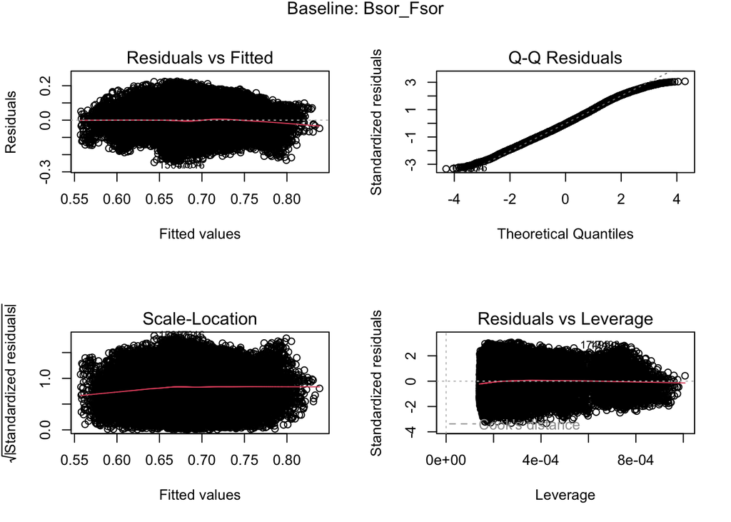

```r
# base (formula in baseline models)
par(mfrow = c(2, 2))
plot(base_Bsor_Fsor)
mtext("Baseline: Bsor_Fsor", outer = TRUE, line = -1)
```

```r
# resid
dat_Bsor_Fsor_resid <- dat %>%
  mutate(Bsor_Fsor_resid = resid(base_Bsor_Fsor))

hist(dat_Bsor_Fsor_resid$Bsor_Fsor_resid,
     breaks = 50,
     main = "Residuals: Bac_beta_sor | constraints")

# symmetric
mr_Bsor_Fsor_sym <- lm(Bsor_Fsor_resid ~ Fungal_cluster_sym, data = dat_Bsor_Fsor_resid)

# directional
mr_Bsor_Fsor_dir <- lm(Bsor_Fsor_resid ~ Fungal_cluster_dir, data = dat_Bsor_Fsor_resid)

# Report residual R² (fraction of remaining variance explained by state/state effect size)
print("residual R²")
```

```
## [1] "residual R²"
```

```r
print("symmetric")
```

```
## [1] "symmetric"
```

```r
summary(mr_Bsor_Fsor_sym)$r.squared
```

```
## [1] 0.2287752
```

```r
print("directional")
```

```
## [1] "directional"
```

```r
summary(mr_Bsor_Fsor_dir)$r.squared
```

```
## [1] 0.2569943
```

```r
# AIC - Lower AIC = better description of residual structure
# answers: Does directionality add explanatory structure beyond unordered state pairing?
AIC(mr_Bsor_Fsor_sym, mr_Bsor_Fsor_dir)
```

```
##                  df       AIC
## mr_Bsor_Fsor_sym 56 -150945.7
## mr_Bsor_Fsor_dir 99 -152990.8
```

```r
mr_Bsor_Fsor_dir
```

```
##
## Call:
## lm(formula = Bsor_Fsor_resid ~ Fungal_cluster_dir, data = dat_Bsor_Fsor_resid)
##
## Coefficients:
##               (Intercept)   Fungal_cluster_dirF1_F10
##                  0.030272                   0.005423
##   Fungal_cluster_dirF1_F2    Fungal_cluster_dirF1_F3
##                 -0.058000                   0.003195
##   Fungal_cluster_dirF1_F4    Fungal_cluster_dirF1_F5
##                 -0.031333                  -0.046481
##   Fungal_cluster_dirF1_F6    Fungal_cluster_dirF1_F7
##                 -0.068506                  -0.041400
##   Fungal_cluster_dirF1_F8    Fungal_cluster_dirF1_F9
##                 -0.081292                  -0.044464
##  Fungal_cluster_dirF10_F1  Fungal_cluster_dirF10_F10
##                 -0.011498                  -0.085197
##  Fungal_cluster_dirF10_F2   Fungal_cluster_dirF10_F3
##                 -0.023217                   0.005285
##  Fungal_cluster_dirF10_F4   Fungal_cluster_dirF10_F5
##                 -0.042864                   0.041013
##  Fungal_cluster_dirF10_F6   Fungal_cluster_dirF10_F7
##                  0.002039                  -0.027667
##  Fungal_cluster_dirF10_F8   Fungal_cluster_dirF10_F9
##                 -0.071538                  -0.056610
##   Fungal_cluster_dirF2_F1   Fungal_cluster_dirF2_F10
##                 -0.002385                   0.023650
##   Fungal_cluster_dirF2_F2    Fungal_cluster_dirF2_F4
##                 -0.133326                  -0.039000
##   Fungal_cluster_dirF2_F5    Fungal_cluster_dirF2_F6
##                 -0.029196                  -0.040814
##   Fungal_cluster_dirF2_F7    Fungal_cluster_dirF2_F8
##                 -0.046953                  -0.067516
##   Fungal_cluster_dirF2_F9    Fungal_cluster_dirF3_F1
##                 -0.056424                   0.031280
##  Fungal_cluster_dirF3_F10    Fungal_cluster_dirF3_F2
##                  0.054431                   0.063306
##   Fungal_cluster_dirF3_F3    Fungal_cluster_dirF3_F4
##                 -0.059556                  -0.004641
##   Fungal_cluster_dirF3_F5    Fungal_cluster_dirF3_F6
```

[output cut: 48 more lines]

```
##                 -0.083181                  -0.072855
##   Fungal_cluster_dirF8_F6    Fungal_cluster_dirF8_F7
##                 -0.064552                  -0.080629
##   Fungal_cluster_dirF8_F8    Fungal_cluster_dirF8_F9
##                 -0.122478                  -0.081473
##   Fungal_cluster_dirF9_F1   Fungal_cluster_dirF9_F10
##                 -0.012850                  -0.084191
##   Fungal_cluster_dirF9_F2    Fungal_cluster_dirF9_F3
##                 -0.074874                   0.024907
##   Fungal_cluster_dirF9_F4    Fungal_cluster_dirF9_F5
##                 -0.067254                   0.005777
##   Fungal_cluster_dirF9_F6    Fungal_cluster_dirF9_F7
##                 -0.009552                  -0.045905
##   Fungal_cluster_dirF9_F8    Fungal_cluster_dirF9_F9
##                 -0.114876                  -0.090192
```

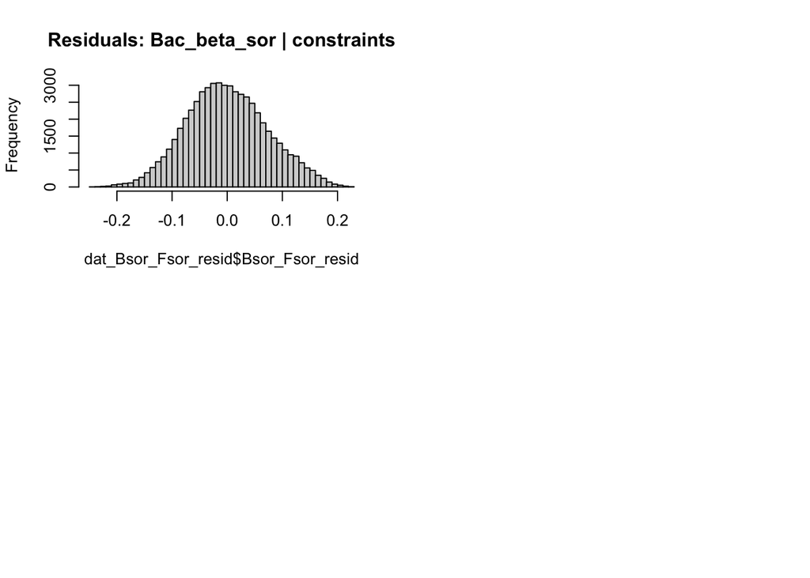

#### 3.4.1.2 F<sub>sim</sub>

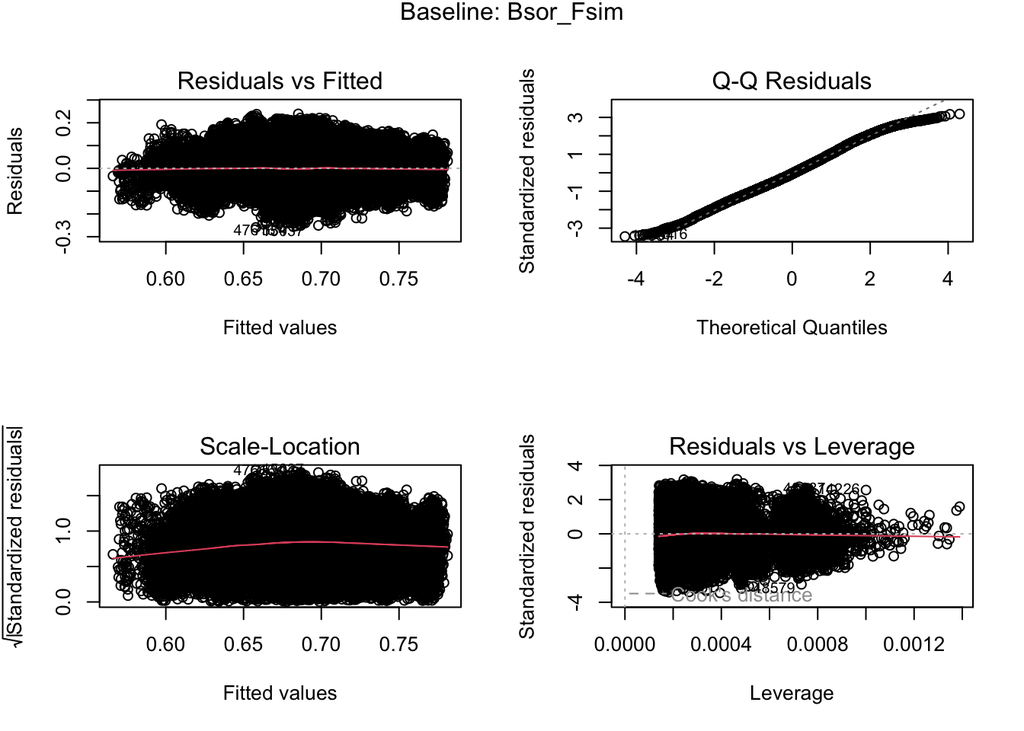

```r
# base (formula in baseline models)

base_Bsor_Fsim <- lm(
  Bac_beta_sor ~ Fun_beta_sim + Bac_pool_sim_diff +
    Fungal_dispersion_diff + Grass_pair,
  data = dat
)

par(mfrow = c(2, 2))
plot(base_Bsor_Fsim)
mtext("Baseline: Bsor_Fsim", outer = TRUE, line = -1)
```

```r
# resid
dat_Bsor_Fsim_resid <- dat %>%
  mutate(Bsor_Fsim_resid = resid(base_Bsor_Fsim))

hist(dat_Bsor_Fsim_resid$Bsor_Fsim_resid,
     breaks = 50,
     main = "Residuals: Bac_beta_sor | constraints")

# symmetric
mr_Bsor_Fsim_sym <- lm(Bsor_Fsim_resid ~ Fungal_cluster_sym, data = dat_Bsor_Fsim_resid)

# directional
mr_Bsor_Fsim_dir <- lm(Bsor_Fsim_resid ~ Fungal_cluster_dir, data = dat_Bsor_Fsim_resid)

# Report residual R² (fraction of remaining variance explained by state/state effect size)
print("residual R²")
```

```
## [1] "residual R²"
```

```r
print("symmetric")
```

```
## [1] "symmetric"
```

```r
summary(mr_Bsor_Fsim_sym)$r.squared
```

```
## [1] 0.2530667
```

```r
print("directional")
```

```
## [1] "directional"
```

```r
summary(mr_Bsor_Fsim_dir)$r.squared
```

```
## [1] 0.2835468
```

```r
# AIC - Lower AIC = better description of residual structure
# answers: Does directionality add explanatory structure beyond unordered state pairing?
AIC(mr_Bsor_Fsim_sym, mr_Bsor_Fsim_dir)
```

```
##                  df       AIC
## mr_Bsor_Fsim_sym 56 -150371.6
## mr_Bsor_Fsim_dir 99 -152667.6
```

```r
mr_Bsor_Fsim_dir
```

```
##
## Call:
## lm(formula = Bsor_Fsim_resid ~ Fungal_cluster_dir, data = dat_Bsor_Fsim_resid)
##
## Coefficients:
##               (Intercept)   Fungal_cluster_dirF1_F10
##                  0.030657                   0.005789
##   Fungal_cluster_dirF1_F2    Fungal_cluster_dirF1_F3
##                 -0.056599                   0.054959
##   Fungal_cluster_dirF1_F4    Fungal_cluster_dirF1_F5
##                 -0.036280                  -0.044674
##   Fungal_cluster_dirF1_F6    Fungal_cluster_dirF1_F7
##                 -0.075064                  -0.047010
##   Fungal_cluster_dirF1_F8    Fungal_cluster_dirF1_F9
##                 -0.084193                  -0.041716
##  Fungal_cluster_dirF10_F1  Fungal_cluster_dirF10_F10
##                 -0.015863                  -0.088989
##  Fungal_cluster_dirF10_F2   Fungal_cluster_dirF10_F3
##                 -0.031572                   0.013323
##  Fungal_cluster_dirF10_F4   Fungal_cluster_dirF10_F5
##                 -0.052776                   0.043411
##  Fungal_cluster_dirF10_F6   Fungal_cluster_dirF10_F7
##                 -0.007901                  -0.035196
##  Fungal_cluster_dirF10_F8   Fungal_cluster_dirF10_F9
##                 -0.074023                  -0.059387
##   Fungal_cluster_dirF2_F1   Fungal_cluster_dirF2_F10
##                  0.001300                   0.023511
##   Fungal_cluster_dirF2_F2    Fungal_cluster_dirF2_F4
##                 -0.142436                  -0.038670
##   Fungal_cluster_dirF2_F5    Fungal_cluster_dirF2_F6
##                 -0.027990                  -0.041474
##   Fungal_cluster_dirF2_F7    Fungal_cluster_dirF2_F8
##                 -0.040515                  -0.068943
##   Fungal_cluster_dirF2_F9    Fungal_cluster_dirF3_F1
##                 -0.042854                   0.063200
##  Fungal_cluster_dirF3_F10    Fungal_cluster_dirF3_F2
##                  0.077765                   0.110183
##   Fungal_cluster_dirF3_F3    Fungal_cluster_dirF3_F4
##                 -0.062938                   0.002932
##   Fungal_cluster_dirF3_F5    Fungal_cluster_dirF3_F6
```

[output cut: 48 more lines]

```
##                 -0.091394                  -0.060954
##   Fungal_cluster_dirF8_F6    Fungal_cluster_dirF8_F7
##                 -0.074540                  -0.088319
##   Fungal_cluster_dirF8_F8    Fungal_cluster_dirF8_F9
##                 -0.117820                  -0.080797
##   Fungal_cluster_dirF9_F1   Fungal_cluster_dirF9_F10
##                 -0.014698                  -0.087331
##   Fungal_cluster_dirF9_F2    Fungal_cluster_dirF9_F3
##                 -0.058284                   0.032590
##   Fungal_cluster_dirF9_F4    Fungal_cluster_dirF9_F5
##                 -0.076608                   0.016010
##   Fungal_cluster_dirF9_F6    Fungal_cluster_dirF9_F7
##                 -0.020861                  -0.056002
##   Fungal_cluster_dirF9_F8    Fungal_cluster_dirF9_F9
##                 -0.117540                  -0.092585
```

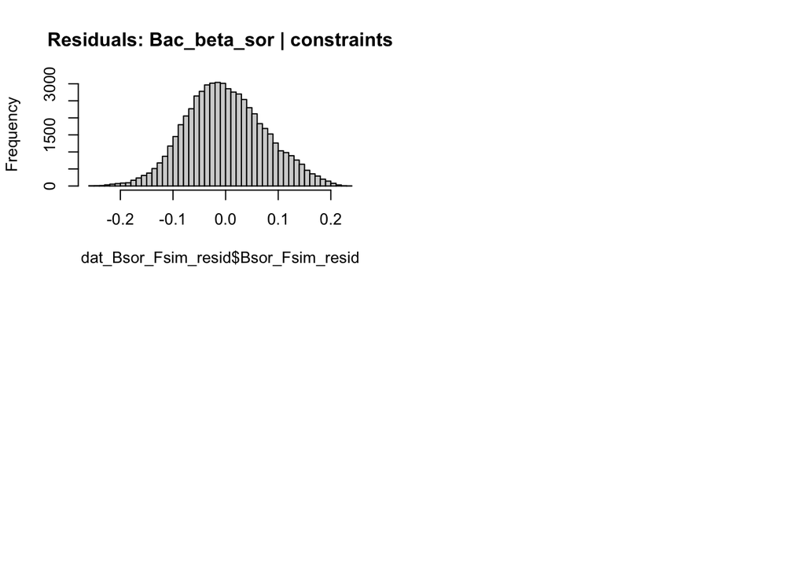

#### 3.4.1.3 F<sub>sne</sub>

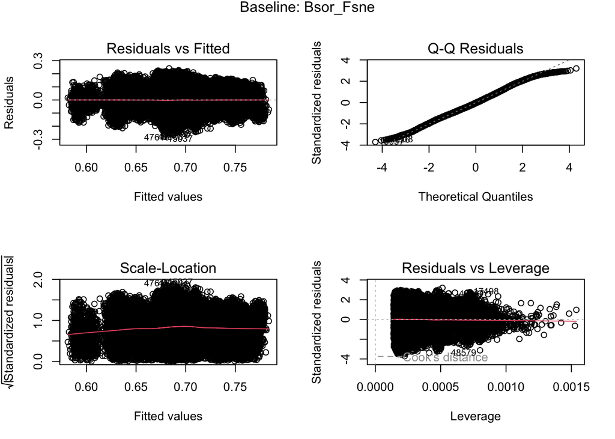

```r
# base (formula in baseline models)
base_Bsor_Fsne <- lm(
  Bac_beta_sor ~ Fun_beta_sne + Bac_pool_sim_diff +
    Fungal_dispersion_diff + Grass_pair,
  data = dat
)

par(mfrow = c(2, 2))
plot(base_Bsor_Fsne)
mtext("Baseline: Bsor_Fsne", outer = TRUE, line = -1)
```

```r
# resid
dat_Bsor_Fsne_resid <- dat %>%
  mutate(Bsor_Fsne_resid = resid(base_Bsor_Fsne))

hist(dat_Bsor_Fsne_resid$Bsor_Fsne_resid,
     breaks = 50,
     main = "Residuals: Bac_beta_sor | constraints")

# symmetric
mr_Bsor_Fsne_sym <- lm(Bsor_Fsne_resid ~ Fungal_cluster_sym, data = dat_Bsor_Fsne_resid)

# directional
mr_Bsor_Fsne_dir <- lm(Bsor_Fsne_resid ~ Fungal_cluster_dir, data = dat_Bsor_Fsne_resid)

# Report residual R² (fraction of remaining variance explained by state/state effect size)
print("residual R²")
```

```
## [1] "residual R²"
```

```r
print("symmetric")
```

```
## [1] "symmetric"
```

```r
summary(mr_Bsor_Fsne_sym)$r.squared
```

```
## [1] 0.2398062
```

```r
print("directional")
```

```
## [1] "directional"
```

```r
summary(mr_Bsor_Fsne_dir)$r.squared
```

```
## [1] 0.2707358
```

```r
# AIC - Lower AIC = better description of residual structure
# answers: Does directionality add explanatory structure beyond unordered state pairing?
AIC(mr_Bsor_Fsne_sym, mr_Bsor_Fsne_dir)
```

```
##                  df       AIC
## mr_Bsor_Fsne_sym 56 -148967.9
## mr_Bsor_Fsne_dir 99 -151256.7
```

```r
mr_Bsor_Fsne_dir
```

```
##
## Call:
## lm(formula = Bsor_Fsne_resid ~ Fungal_cluster_dir, data = dat_Bsor_Fsne_resid)
##
## Coefficients:
##               (Intercept)   Fungal_cluster_dirF1_F10
##                 0.0179183                  0.0225889
##   Fungal_cluster_dirF1_F2    Fungal_cluster_dirF1_F3
##                -0.0455215                  0.0690860
##   Fungal_cluster_dirF1_F4    Fungal_cluster_dirF1_F5
##                -0.0200223                 -0.0312018
##   Fungal_cluster_dirF1_F6    Fungal_cluster_dirF1_F7
##                -0.0633922                 -0.0316700
##   Fungal_cluster_dirF1_F8    Fungal_cluster_dirF1_F9
##                -0.0714999                 -0.0272419
##  Fungal_cluster_dirF10_F1  Fungal_cluster_dirF10_F10
##                -0.0005614                 -0.0755197
##  Fungal_cluster_dirF10_F2   Fungal_cluster_dirF10_F3
##                -0.0170942                  0.0317315
##  Fungal_cluster_dirF10_F4   Fungal_cluster_dirF10_F5
##                -0.0354923                  0.0613982
##  Fungal_cluster_dirF10_F6   Fungal_cluster_dirF10_F7
##                 0.0114398                 -0.0178795
##  Fungal_cluster_dirF10_F8   Fungal_cluster_dirF10_F9
##                -0.0557528                 -0.0441017
##   Fungal_cluster_dirF2_F1   Fungal_cluster_dirF2_F10
##                 0.0136118                  0.0398977
##   Fungal_cluster_dirF2_F2    Fungal_cluster_dirF2_F4
##                -0.1411195                 -0.0229856
##   Fungal_cluster_dirF2_F5    Fungal_cluster_dirF2_F6
##                -0.0137148                 -0.0287797
##   Fungal_cluster_dirF2_F7    Fungal_cluster_dirF2_F8
##                -0.0255770                 -0.0541804
##   Fungal_cluster_dirF2_F9    Fungal_cluster_dirF3_F1
##                -0.0287234                  0.0769354
##  Fungal_cluster_dirF3_F10    Fungal_cluster_dirF3_F2
##                 0.0981331                  0.1229796
##   Fungal_cluster_dirF3_F3    Fungal_cluster_dirF3_F4
##                -0.0559759                  0.0172348
##   Fungal_cluster_dirF3_F5    Fungal_cluster_dirF3_F6
```

[output cut: 48 more lines]

```
##                -0.0758799                 -0.0451238
##   Fungal_cluster_dirF8_F6    Fungal_cluster_dirF8_F7
##                -0.0586357                 -0.0726347
##   Fungal_cluster_dirF8_F8    Fungal_cluster_dirF8_F9
##                -0.1036185                 -0.0634515
##   Fungal_cluster_dirF9_F1   Fungal_cluster_dirF9_F10
##                -0.0005069                 -0.0719982
##   Fungal_cluster_dirF9_F2    Fungal_cluster_dirF9_F3
##                -0.0455601                  0.0499993
##   Fungal_cluster_dirF9_F4    Fungal_cluster_dirF9_F5
##                -0.0607208                  0.0323311
##   Fungal_cluster_dirF9_F6    Fungal_cluster_dirF9_F7
##                -0.0020723                 -0.0395937
##   Fungal_cluster_dirF9_F8    Fungal_cluster_dirF9_F9
##                -0.1020320                 -0.0798413
```

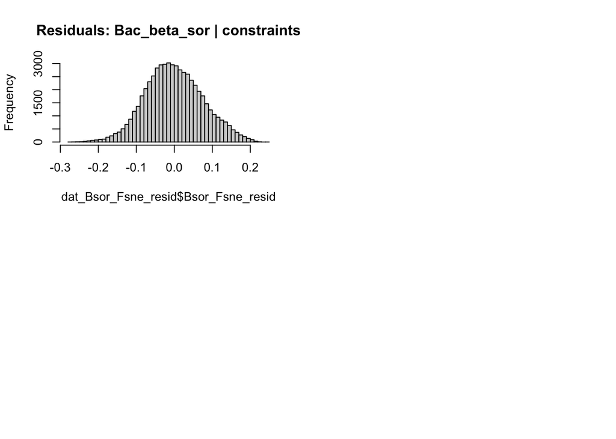

### 3.4.2 y = Bac<sub>sim</sub>

#### 3.4.2.1 F<sub>sor</sub>

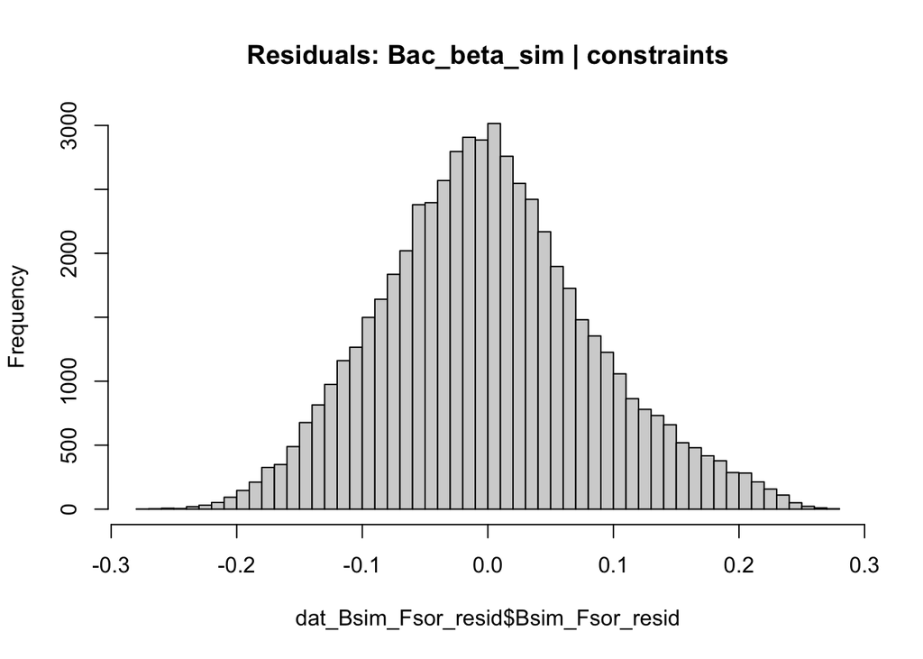

```r
# base (formula in baseline models)
base_Bsim_Fsor <- lm(
  Bac_beta_sim ~ Fun_beta_sor + Bac_pool_sim_diff +
    Fungal_dispersion_diff + Grass_pair,
  data = dat
)

# resid
dat_Bsim_Fsor_resid <- dat %>%
  mutate(Bsim_Fsor_resid = resid(base_Bsim_Fsor))

hist(dat_Bsim_Fsor_resid$Bsim_Fsor_resid,
     breaks = 50,
     main = "Residuals: Bac_beta_sim | constraints")
```

```r
# symmetric
mr_Bsim_Fsor_sym <- lm(Bsim_Fsor_resid ~ Fungal_cluster_sym, data = dat_Bsim_Fsor_resid)

# directional
mr_Bsim_Fsor_dir <- lm(Bsim_Fsor_resid ~ Fungal_cluster_dir, data = dat_Bsim_Fsor_resid)

# Report residual R² (fraction of remaining variance explained by state/state effect size)
print("residual R²")
```

```
## [1] "residual R²"
```

```r
print("symmetric")
```

```
## [1] "symmetric"
```

```r
summary(mr_Bsim_Fsor_sym)$r.squared
```

```
## [1] 0.1890217
```

```r
print("directional")
```

```
## [1] "directional"
```

```r
summary(mr_Bsim_Fsor_dir)$r.squared
```

```
## [1] 0.210885
```

```r
# AIC - Lower AIC = better description of residual structure
# answers: Does directionality add explanatory structure beyond unordered state pairing?
AIC(mr_Bsim_Fsor_sym, mr_Bsim_Fsor_dir)
```

```
##                  df       AIC
## mr_Bsim_Fsor_sym 56 -132381.9
## mr_Bsim_Fsor_dir 99 -133858.4
```

```r
mr_Bsim_Fsor_dir
```

```
##
## Call:
## lm(formula = Bsim_Fsor_resid ~ Fungal_cluster_dir, data = dat_Bsim_Fsor_resid)
##
## Coefficients:
##               (Intercept)   Fungal_cluster_dirF1_F10
##                 0.0340284                 -0.0161588
##   Fungal_cluster_dirF1_F2    Fungal_cluster_dirF1_F3
##                -0.0507930                  0.0504976
##   Fungal_cluster_dirF1_F4    Fungal_cluster_dirF1_F5
##                -0.0408956                 -0.0399630
##   Fungal_cluster_dirF1_F6    Fungal_cluster_dirF1_F7
##                -0.0860889                 -0.0353127
##   Fungal_cluster_dirF1_F8    Fungal_cluster_dirF1_F9
##                -0.0857101                 -0.0353098
##  Fungal_cluster_dirF10_F1  Fungal_cluster_dirF10_F10
##                -0.0076231                 -0.1036569
##  Fungal_cluster_dirF10_F2   Fungal_cluster_dirF10_F3
##                -0.0426829                  0.0110664
##  Fungal_cluster_dirF10_F4   Fungal_cluster_dirF10_F5
##                -0.0356814                  0.0564931
##  Fungal_cluster_dirF10_F6   Fungal_cluster_dirF10_F7
##                -0.0183739                 -0.0267014
##  Fungal_cluster_dirF10_F8   Fungal_cluster_dirF10_F9
##                -0.0684398                 -0.0550177
##   Fungal_cluster_dirF2_F1   Fungal_cluster_dirF2_F10
##                -0.0274754                 -0.0391582
##   Fungal_cluster_dirF2_F2    Fungal_cluster_dirF2_F4
##                -0.1113999                 -0.0999531
##   Fungal_cluster_dirF2_F5    Fungal_cluster_dirF2_F6
##                -0.0419053                  0.0038693
##   Fungal_cluster_dirF2_F7    Fungal_cluster_dirF2_F8
##                -0.0344824                 -0.0439303
##   Fungal_cluster_dirF2_F9    Fungal_cluster_dirF3_F1
##                -0.0671110                 -0.0268266
##  Fungal_cluster_dirF3_F10    Fungal_cluster_dirF3_F2
##                 0.0775283                 -0.0002994
##   Fungal_cluster_dirF3_F3    Fungal_cluster_dirF3_F4
##                -0.1069014                 -0.0098968
##   Fungal_cluster_dirF3_F5    Fungal_cluster_dirF3_F6
```

[output cut: 48 more lines]

```
##                -0.1074423                 -0.0529374
##   Fungal_cluster_dirF8_F6    Fungal_cluster_dirF8_F7
##                -0.0756572                 -0.0802794
##   Fungal_cluster_dirF8_F8    Fungal_cluster_dirF8_F9
##                -0.1128809                 -0.0804153
##   Fungal_cluster_dirF9_F1   Fungal_cluster_dirF9_F10
##                -0.0069723                 -0.1063810
##   Fungal_cluster_dirF9_F2    Fungal_cluster_dirF9_F3
##                -0.0577480                  0.0171988
##   Fungal_cluster_dirF9_F4    Fungal_cluster_dirF9_F5
##                -0.1052350                  0.0223387
##   Fungal_cluster_dirF9_F6    Fungal_cluster_dirF9_F7
##                -0.0001287                 -0.0412390
##   Fungal_cluster_dirF9_F8    Fungal_cluster_dirF9_F9
##                -0.1140786                 -0.1010318
```

#### 3.4.2.2 F<sub>sim</sub>

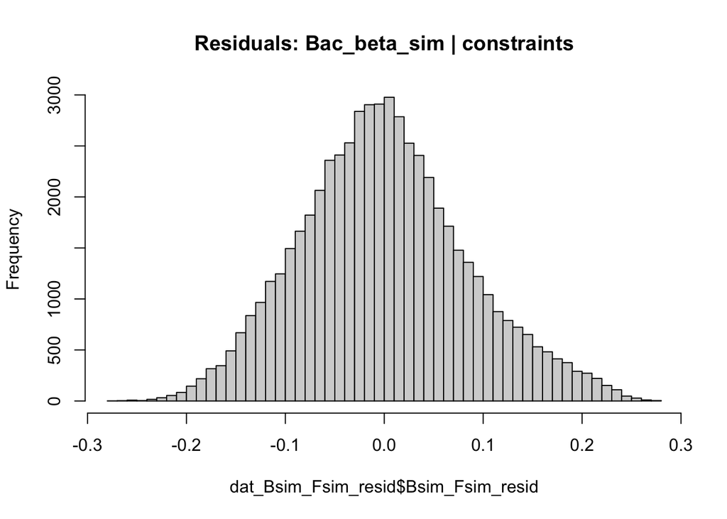

```r
# base (formula in baseline models)

# resid
dat_Bsim_Fsim_resid <- dat %>%
  mutate(Bsim_Fsim_resid = resid(base_Bsim_Fsim))

hist(dat_Bsim_Fsim_resid$Bsim_Fsim_resid,
     breaks = 50,
     main = "Residuals: Bac_beta_sim | constraints")
```

```r
# symmetric
mr_Bsim_Fsim_sym <- lm(Bsim_Fsim_resid ~ Fungal_cluster_sym, data = dat_Bsim_Fsim_resid)

# directional
mr_Bsim_Fsim_dir <- lm(Bsim_Fsim_resid ~ Fungal_cluster_dir, data = dat_Bsim_Fsim_resid)

# Report residual R² (fraction of remaining variance explained by state/state effect size)
print("residual R²")
```

```
## [1] "residual R²"
```

```r
print("symmetric")
```

```
## [1] "symmetric"
```

```r
summary(mr_Bsim_Fsim_sym)$r.squared
```

```
## [1] 0.192111
```

```r
print("directional")
```

```
## [1] "directional"
```

```r
summary(mr_Bsim_Fsim_dir)$r.squared
```

```
## [1] 0.2137395
```

```r
# AIC - Lower AIC = better description of residual structure
# answers: Does directionality add explanatory structure beyond unordered state pairing?
AIC(mr_Bsim_Fsim_sym, mr_Bsim_Fsim_dir)
```

```
##                  df       AIC
## mr_Bsim_Fsim_sym 56 -132640.3
## mr_Bsim_Fsim_dir 99 -134105.8
```

```r
mr_Bsim_Fsim_dir
```

```
##
## Call:
## lm(formula = Bsim_Fsim_resid ~ Fungal_cluster_dir, data = dat_Bsim_Fsim_resid)
##
## Coefficients:
##               (Intercept)   Fungal_cluster_dirF1_F10
##                  0.035829                  -0.017015
##   Fungal_cluster_dirF1_F2    Fungal_cluster_dirF1_F3
##                 -0.052635                   0.048354
##   Fungal_cluster_dirF1_F4    Fungal_cluster_dirF1_F5
##                 -0.042073                  -0.041275
##   Fungal_cluster_dirF1_F6    Fungal_cluster_dirF1_F7
##                 -0.087962                  -0.037426
##   Fungal_cluster_dirF1_F8    Fungal_cluster_dirF1_F9
##                 -0.087420                  -0.037041
##  Fungal_cluster_dirF10_F1  Fungal_cluster_dirF10_F10
##                 -0.009179                  -0.105666
##  Fungal_cluster_dirF10_F2   Fungal_cluster_dirF10_F3
##                 -0.044395                   0.008075
##  Fungal_cluster_dirF10_F4   Fungal_cluster_dirF10_F5
##                 -0.038634                   0.053412
##  Fungal_cluster_dirF10_F6   Fungal_cluster_dirF10_F7
##                 -0.021476                  -0.029377
##  Fungal_cluster_dirF10_F8   Fungal_cluster_dirF10_F9
##                 -0.071152                  -0.057342
##   Fungal_cluster_dirF2_F1   Fungal_cluster_dirF2_F10
##                 -0.029552                  -0.040730
##   Fungal_cluster_dirF2_F2    Fungal_cluster_dirF2_F4
##                 -0.111486                  -0.101542
##   Fungal_cluster_dirF2_F5    Fungal_cluster_dirF2_F6
##                 -0.043916                   0.001594
##   Fungal_cluster_dirF2_F7    Fungal_cluster_dirF2_F8
##                 -0.036818                  -0.046903
##   Fungal_cluster_dirF2_F9    Fungal_cluster_dirF3_F1
##                 -0.069223                  -0.028271
##  Fungal_cluster_dirF3_F10    Fungal_cluster_dirF3_F2
##                  0.074430                  -0.002026
##   Fungal_cluster_dirF3_F3    Fungal_cluster_dirF3_F4
##                 -0.108259                  -0.011924
##   Fungal_cluster_dirF3_F5    Fungal_cluster_dirF3_F6
```

[output cut: 48 more lines]

```
##                 -0.109791                  -0.055552
##   Fungal_cluster_dirF8_F6    Fungal_cluster_dirF8_F7
##                 -0.078217                  -0.082807
##   Fungal_cluster_dirF8_F8    Fungal_cluster_dirF8_F9
##                 -0.114715                  -0.083151
##   Fungal_cluster_dirF9_F1   Fungal_cluster_dirF9_F10
##                 -0.008899                  -0.108117
##   Fungal_cluster_dirF9_F2    Fungal_cluster_dirF9_F3
##                 -0.059478                   0.014340
##   Fungal_cluster_dirF9_F4    Fungal_cluster_dirF9_F5
##                 -0.107557                   0.019701
##   Fungal_cluster_dirF9_F6    Fungal_cluster_dirF9_F7
##                 -0.003187                  -0.043757
##   Fungal_cluster_dirF9_F8    Fungal_cluster_dirF9_F9
##                 -0.116256                  -0.102619
```

#### 3.4.2.3 F<sub>sne</sub>

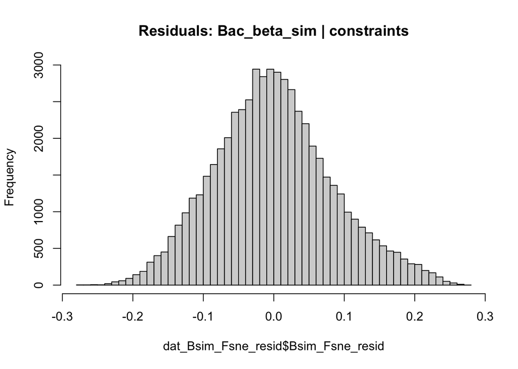

```r
# base (formula in baseline models)
base_Bsim_Fsne <- lm(
  Bac_beta_sim ~ Fun_beta_sne + Bac_pool_sim_diff +
    Fungal_dispersion_diff + Grass_pair,
  data = dat
)

# resid
dat_Bsim_Fsne_resid <- dat %>%
  mutate(Bsim_Fsne_resid = resid(base_Bsim_Fsne))

hist(dat_Bsim_Fsne_resid$Bsim_Fsne_resid,
     breaks = 50,
     main = "Residuals: Bac_beta_sim | constraints")
```

```r
# symmetric
mr_Bsim_Fsne_sym <- lm(Bsim_Fsne_resid ~ Fungal_cluster_sym, data = dat_Bsim_Fsne_resid)

# directional
mr_Bsim_Fsne_dir <- lm(Bsim_Fsne_resid ~ Fungal_cluster_dir, data = dat_Bsim_Fsne_resid)

# Report residual R² (fraction of remaining variance explained by state/state effect size)
print("residual R²")
```

```
## [1] "residual R²"
```

```r
print("symmetric")
```

```
## [1] "symmetric"
```

```r
summary(mr_Bsim_Fsne_sym)$r.squared
```

```
## [1] 0.1894712
```

```r
print("directional")
```

```
## [1] "directional"
```

```r
summary(mr_Bsim_Fsne_dir)$r.squared
```

```
## [1] 0.2104907
```

```r
# AIC - Lower AIC = better description of residual structure
# answers: Does directionality add explanatory structure beyond unordered state pairing?
AIC(mr_Bsim_Fsne_sym, mr_Bsim_Fsne_dir)
```

```
##                  df       AIC
## mr_Bsim_Fsne_sym 56 -132561.3
## mr_Bsim_Fsne_dir 99 -133977.5
```

```r
mr_Bsim_Fsne_dir
```

```
##
## Call:
## lm(formula = Bsim_Fsne_resid ~ Fungal_cluster_dir, data = dat_Bsim_Fsne_resid)
##
## Coefficients:
##               (Intercept)   Fungal_cluster_dirF1_F10
##                 0.0310520                 -0.0033417
##   Fungal_cluster_dirF1_F2    Fungal_cluster_dirF1_F3
##                -0.0498216                  0.0529360
##   Fungal_cluster_dirF1_F4    Fungal_cluster_dirF1_F5
##                -0.0305332                 -0.0333473
##   Fungal_cluster_dirF1_F6    Fungal_cluster_dirF1_F7
##                -0.0846682                 -0.0314065
##   Fungal_cluster_dirF1_F8    Fungal_cluster_dirF1_F9
##                -0.0822484                 -0.0300831
##  Fungal_cluster_dirF10_F1  Fungal_cluster_dirF10_F10
##                -0.0004951                 -0.1011270
##  Fungal_cluster_dirF10_F2   Fungal_cluster_dirF10_F3
##                -0.0373444                  0.0130866
##  Fungal_cluster_dirF10_F4   Fungal_cluster_dirF10_F5
##                -0.0346264                  0.0575417
##  Fungal_cluster_dirF10_F6   Fungal_cluster_dirF10_F7
##                -0.0160116                 -0.0239892
##  Fungal_cluster_dirF10_F8   Fungal_cluster_dirF10_F9
##                -0.0649304                 -0.0524038
##   Fungal_cluster_dirF2_F1   Fungal_cluster_dirF2_F10
##                -0.0265649                 -0.0309686
##   Fungal_cluster_dirF2_F2    Fungal_cluster_dirF2_F4
##                -0.1105042                 -0.0926107
##   Fungal_cluster_dirF2_F5    Fungal_cluster_dirF2_F6
##                -0.0385291                  0.0040197
##   Fungal_cluster_dirF2_F7    Fungal_cluster_dirF2_F8
##                -0.0323036                 -0.0456694
##   Fungal_cluster_dirF2_F9    Fungal_cluster_dirF3_F1
##                -0.0644810                 -0.0207059
##  Fungal_cluster_dirF3_F10    Fungal_cluster_dirF3_F2
##                 0.0810018                  0.0031704
##   Fungal_cluster_dirF3_F3    Fungal_cluster_dirF3_F4
##                -0.1074623                 -0.0065862
##   Fungal_cluster_dirF3_F5    Fungal_cluster_dirF3_F6
```

[output cut: 48 more lines]

```
##                -0.1047294                 -0.0514473
##   Fungal_cluster_dirF8_F6    Fungal_cluster_dirF8_F7
##                -0.0737644                 -0.0784356
##   Fungal_cluster_dirF8_F8    Fungal_cluster_dirF8_F9
##                -0.1085482                 -0.0780227
##   Fungal_cluster_dirF9_F1   Fungal_cluster_dirF9_F10
##                -0.0031905                 -0.1002718
##   Fungal_cluster_dirF9_F2    Fungal_cluster_dirF9_F3
##                -0.0543764                  0.0189339
##   Fungal_cluster_dirF9_F4    Fungal_cluster_dirF9_F5
##                -0.1019687                  0.0242142
##   Fungal_cluster_dirF9_F6    Fungal_cluster_dirF9_F7
##                 0.0019036                 -0.0385703
##   Fungal_cluster_dirF9_F8    Fungal_cluster_dirF9_F9
##                -0.1103698                 -0.0967997
```

### 3.4.3 y = Bac<sub>sne</sub>

#### 3.4.3.1 F<sub>sor</sub>

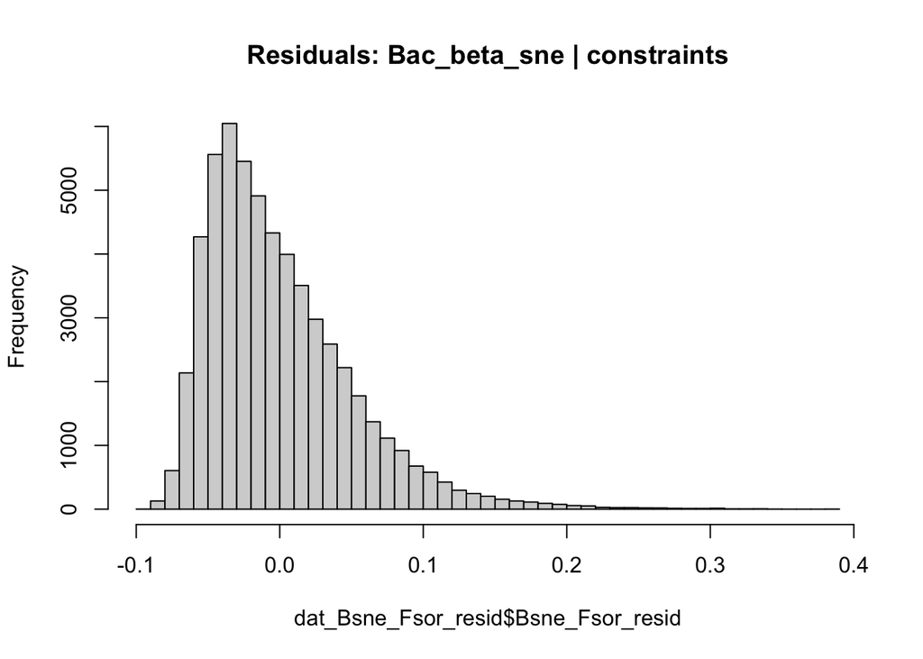

```r
# base (formula in baseline models)
base_Bsne_Fsor <- lm(
  Bac_beta_sne ~ Fun_beta_sor + Bac_pool_sim_diff +
    Fungal_dispersion_diff + Grass_pair,
  data = dat
)

# resid
dat_Bsne_Fsor_resid <- dat %>%
  mutate(Bsne_Fsor_resid = resid(base_Bsne_Fsor))

hist(dat_Bsne_Fsor_resid$Bsne_Fsor_resid,
     breaks = 50,
     main = "Residuals: Bac_beta_sne | constraints")
```

```r
# symmetric
mr_Bsne_Fsor_sym <- lm(Bsne_Fsor_resid ~ Fungal_cluster_sym, data = dat_Bsne_Fsor_resid)

# directional
mr_Bsne_Fsor_dir <- lm(Bsne_Fsor_resid ~ Fungal_cluster_dir, data = dat_Bsne_Fsor_resid)

# Report residual R² (fraction of remaining variance explained by state/state effect size)
print("residual R²")
```

```
## [1] "residual R²"
```

```r
print("symmetric")
```

```
## [1] "symmetric"
```

```r
summary(mr_Bsne_Fsor_sym)$r.squared
```

```
## [1] 0.1259918
```

```r
print("directional")
```

```
## [1] "directional"
```

```r
summary(mr_Bsne_Fsor_dir)$r.squared
```

```
## [1] 0.1455395
```

```r
# AIC - Lower AIC = better description of residual structure
# answers: Does directionality add explanatory structure beyond unordered state pairing?
AIC(mr_Bsne_Fsor_sym, mr_Bsne_Fsor_dir)
```

```
##                  df       AIC
## mr_Bsne_Fsor_sym 56 -185595.4
## mr_Bsne_Fsor_dir 99 -186802.6
```

```r
mr_Bsne_Fsor_dir
```

```
##
## Call:
## lm(formula = Bsne_Fsor_resid ~ Fungal_cluster_dir, data = dat_Bsne_Fsor_resid)
##
## Coefficients:
##               (Intercept)   Fungal_cluster_dirF1_F10
##                -3.012e-03                  1.857e-02
##   Fungal_cluster_dirF1_F2    Fungal_cluster_dirF1_F3
##                -5.591e-03                  4.345e-03
##   Fungal_cluster_dirF1_F4    Fungal_cluster_dirF1_F5
##                 2.014e-03                 -6.224e-03
##   Fungal_cluster_dirF1_F6    Fungal_cluster_dirF1_F7
##                 1.112e-02                 -1.224e-02
##   Fungal_cluster_dirF1_F8    Fungal_cluster_dirF1_F9
##                 9.974e-04                 -7.417e-03
##  Fungal_cluster_dirF10_F1  Fungal_cluster_dirF10_F10
##                -9.832e-03                  1.449e-02
##  Fungal_cluster_dirF10_F2   Fungal_cluster_dirF10_F3
##                 1.006e-02                  2.483e-03
##  Fungal_cluster_dirF10_F4   Fungal_cluster_dirF10_F5
##                -1.661e-02                 -1.256e-02
##  Fungal_cluster_dirF10_F6   Fungal_cluster_dirF10_F7
##                 1.063e-02                 -8.547e-03
##  Fungal_cluster_dirF10_F8   Fungal_cluster_dirF10_F9
##                -5.850e-03                 -4.487e-03
##   Fungal_cluster_dirF2_F1   Fungal_cluster_dirF2_F10
##                 2.907e-02                  6.078e-02
##   Fungal_cluster_dirF2_F2    Fungal_cluster_dirF2_F4
##                -3.127e-02                  5.964e-02
##   Fungal_cluster_dirF2_F5    Fungal_cluster_dirF2_F6
##                 1.350e-02                 -4.478e-02
##   Fungal_cluster_dirF2_F7    Fungal_cluster_dirF2_F8
##                -6.025e-03                 -2.373e-02
##   Fungal_cluster_dirF2_F9    Fungal_cluster_dirF3_F1
##                 2.408e-02                  8.869e-02
##  Fungal_cluster_dirF3_F10    Fungal_cluster_dirF3_F2
##                 8.174e-05                  1.100e-01
##   Fungal_cluster_dirF3_F3    Fungal_cluster_dirF3_F4
##                 4.448e-02                  1.244e-02
##   Fungal_cluster_dirF3_F5    Fungal_cluster_dirF3_F6
```

[output cut: 48 more lines]

```
##                 1.591e-02                 -7.742e-03
##   Fungal_cluster_dirF8_F6    Fungal_cluster_dirF8_F7
##                 1.264e-03                 -7.888e-03
##   Fungal_cluster_dirF8_F8    Fungal_cluster_dirF8_F9
##                -5.671e-03                 -3.286e-04
##   Fungal_cluster_dirF9_F1   Fungal_cluster_dirF9_F10
##                -8.278e-03                  1.779e-02
##   Fungal_cluster_dirF9_F2    Fungal_cluster_dirF9_F3
##                -1.025e-03                  1.566e-02
##   Fungal_cluster_dirF9_F4    Fungal_cluster_dirF9_F5
##                 2.832e-02                 -6.156e-03
##   Fungal_cluster_dirF9_F6    Fungal_cluster_dirF9_F7
##                -2.049e-02                 -1.484e-02
##   Fungal_cluster_dirF9_F8    Fungal_cluster_dirF9_F9
##                -3.926e-03                  7.678e-03
```

#### 3.4.3.2 F<sub>sim</sub>

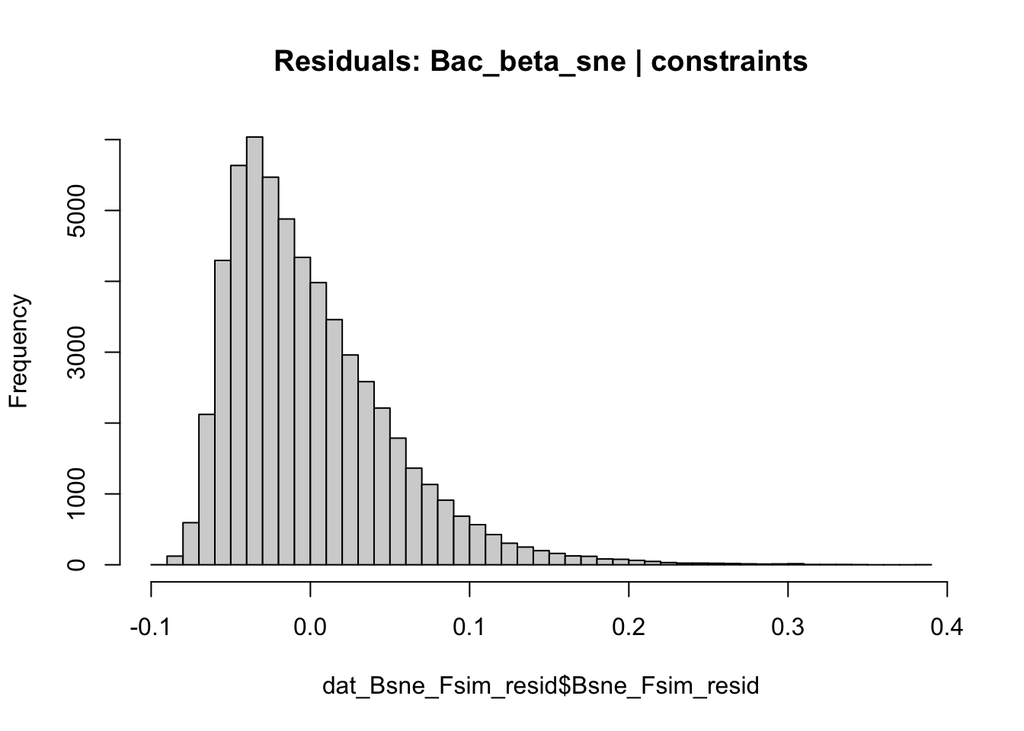

```r
# base (formula in baseline models)
base_Bsne_Fsim <- lm(
  Bac_beta_sne ~ Fun_beta_sim + Bac_pool_sim_diff +
    Fungal_dispersion_diff + Grass_pair,
  data = dat
)

# resid
dat_Bsne_Fsim_resid <- dat %>%
  mutate(Bsne_Fsim_resid = resid(base_Bsne_Fsim))

hist(dat_Bsne_Fsim_resid$Bsne_Fsim_resid,
     breaks = 50,
     main = "Residuals: Bac_beta_sne | constraints")
```

```r
# symmetric
mr_Bsne_Fsim_sym <- lm(Bsne_Fsim_resid ~ Fungal_cluster_sym, data = dat_Bsne_Fsim_resid)

# directional
mr_Bsne_Fsim_dir <- lm(Bsne_Fsim_resid ~ Fungal_cluster_dir, data = dat_Bsne_Fsim_resid)

# Report residual R² (fraction of remaining variance explained by state/state effect size)
print("residual R²")
```

```
## [1] "residual R²"
```

```r
print("symmetric")
```

```
## [1] "symmetric"
```

```r
summary(mr_Bsne_Fsim_sym)$r.squared
```

```
## [1] 0.1275715
```

```r
print("directional")
```

```
## [1] "directional"
```

```r
summary(mr_Bsne_Fsim_dir)$r.squared
```

```
## [1] 0.1472244
```

```r
# AIC - Lower AIC = better description of residual structure
# answers: Does directionality add explanatory structure beyond unordered state pairing?
AIC(mr_Bsne_Fsim_sym, mr_Bsne_Fsim_dir)
```

```
##                  df       AIC
## mr_Bsne_Fsim_sym 56 -185538.2
## mr_Bsne_Fsim_dir 99 -186754.9
```

```r
mr_Bsne_Fsim_dir
```

```
##
## Call:
## lm(formula = Bsne_Fsim_resid ~ Fungal_cluster_dir, data = dat_Bsne_Fsim_resid)
##
## Coefficients:
##               (Intercept)   Fungal_cluster_dirF1_F10
##                -0.0051717                  0.0228037
##   Fungal_cluster_dirF1_F2    Fungal_cluster_dirF1_F3
##                -0.0039644                  0.0066057
##   Fungal_cluster_dirF1_F4    Fungal_cluster_dirF1_F5
##                 0.0057929                 -0.0033992
##   Fungal_cluster_dirF1_F6    Fungal_cluster_dirF1_F7
##                 0.0128978                 -0.0095843
##   Fungal_cluster_dirF1_F8    Fungal_cluster_dirF1_F9
##                 0.0032268                 -0.0046752
##  Fungal_cluster_dirF10_F1  Fungal_cluster_dirF10_F10
##                -0.0066837                  0.0166774
##  Fungal_cluster_dirF10_F2   Fungal_cluster_dirF10_F3
##                 0.0128229                  0.0052486
##  Fungal_cluster_dirF10_F4   Fungal_cluster_dirF10_F5
##                -0.0141420                 -0.0100010
##  Fungal_cluster_dirF10_F6   Fungal_cluster_dirF10_F7
##                 0.0135752                 -0.0058189
##  Fungal_cluster_dirF10_F8   Fungal_cluster_dirF10_F9
##                -0.0028710                 -0.0020450
##   Fungal_cluster_dirF2_F1   Fungal_cluster_dirF2_F10
##                 0.0308512                  0.0642410
##   Fungal_cluster_dirF2_F2    Fungal_cluster_dirF2_F4
##                -0.0309505                  0.0628721
##   Fungal_cluster_dirF2_F5    Fungal_cluster_dirF2_F6
##                 0.0159262                 -0.0430682
##   Fungal_cluster_dirF2_F7    Fungal_cluster_dirF2_F8
##                -0.0036968                 -0.0220400
##   Fungal_cluster_dirF2_F9    Fungal_cluster_dirF3_F1
##                 0.0263693                  0.0914712
##  Fungal_cluster_dirF3_F10    Fungal_cluster_dirF3_F2
##                 0.0033349                  0.1122096
##   Fungal_cluster_dirF3_F3    Fungal_cluster_dirF3_F4
##                 0.0453214                  0.0148557
##   Fungal_cluster_dirF3_F5    Fungal_cluster_dirF3_F6
```

[output cut: 48 more lines]

```
##                 0.0183968                 -0.0054019
##   Fungal_cluster_dirF8_F6    Fungal_cluster_dirF8_F7
##                 0.0036768                 -0.0055121
##   Fungal_cluster_dirF8_F8    Fungal_cluster_dirF8_F9
##                -0.0031054                  0.0023536
##   Fungal_cluster_dirF9_F1   Fungal_cluster_dirF9_F10
##                -0.0057996                  0.0207859
##   Fungal_cluster_dirF9_F2    Fungal_cluster_dirF9_F3
##                 0.0011946                  0.0182505
##   Fungal_cluster_dirF9_F4    Fungal_cluster_dirF9_F5
##                 0.0309487                 -0.0036909
##   Fungal_cluster_dirF9_F6    Fungal_cluster_dirF9_F7
##                -0.0176740                 -0.0122445
##   Fungal_cluster_dirF9_F8    Fungal_cluster_dirF9_F9
##                -0.0012836                  0.0100338
```

#### 3.4.3.3 F<sub>sne</sub>

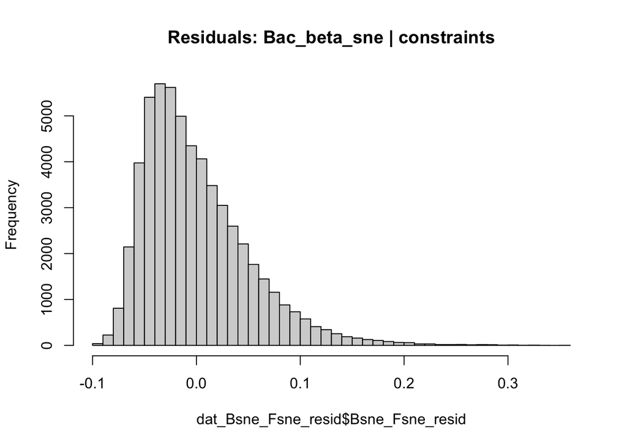

```r
# base (formula in baseline models)

# resid
dat_Bsne_Fsne_resid <- dat %>%
  mutate(Bsne_Fsne_resid = resid(base_Bsne_Fsne))

hist(dat_Bsne_Fsne_resid$Bsne_Fsne_resid,
     breaks = 50,
     main = "Residuals: Bac_beta_sne | constraints")
```

```r
# symmetric
mr_Bsne_Fsne_sym <- lm(Bsne_Fsne_resid ~ Fungal_cluster_sym, data = dat_Bsne_Fsne_resid)

# directional
mr_Bsne_Fsne_dir <- lm(Bsne_Fsne_resid ~ Fungal_cluster_dir, data = dat_Bsne_Fsne_resid)

# Report residual R² (fraction of remaining variance explained by state/state effect size)
print("residual R²")
```

```
## [1] "residual R²"
```

```r
print("symmetric")
```

```
## [1] "symmetric"
```

```r
summary(mr_Bsne_Fsne_sym)$r.squared
```

```
## [1] 0.1261722
```

```r
print("directional")
```

```
## [1] "directional"
```

```r
summary(mr_Bsne_Fsne_dir)$r.squared
```

```
## [1] 0.1449813
```

```r
# AIC - Lower AIC = better description of residual structure
# answers: Does directionality add explanatory structure beyond unordered state pairing?
AIC(mr_Bsne_Fsne_sym, mr_Bsne_Fsne_dir)
```

```
##                  df       AIC
## mr_Bsne_Fsne_sym 56 -186511.5
## mr_Bsne_Fsne_dir 99 -187669.5
```

```r
mr_Bsne_Fsne_dir
```

```
##
## Call:
## lm(formula = Bsne_Fsne_resid ~ Fungal_cluster_dir, data = dat_Bsne_Fsne_resid)
##
## Coefficients:
##               (Intercept)   Fungal_cluster_dirF1_F10
##                -0.0111487                  0.0245574
##   Fungal_cluster_dirF1_F2    Fungal_cluster_dirF1_F3
##                -0.0041481                 -0.0075998
##   Fungal_cluster_dirF1_F4    Fungal_cluster_dirF1_F5
##                 0.0119925                 -0.0012915
##   Fungal_cluster_dirF1_F6    Fungal_cluster_dirF1_F7
##                 0.0221468                  0.0006323
##   Fungal_cluster_dirF1_F8    Fungal_cluster_dirF1_F9
##                 0.0096604                 -0.0001159
##  Fungal_cluster_dirF10_F1  Fungal_cluster_dirF10_F10
##                 0.0002570                  0.0228543
##  Fungal_cluster_dirF10_F2   Fungal_cluster_dirF10_F3
##                 0.0182297                  0.0144074
##  Fungal_cluster_dirF10_F4   Fungal_cluster_dirF10_F5
##                 0.0006379                 -0.0001400
##  Fungal_cluster_dirF10_F6   Fungal_cluster_dirF10_F7
##                 0.0268190                  0.0049622
##  Fungal_cluster_dirF10_F8   Fungal_cluster_dirF10_F9
##                 0.0065124                  0.0063892
##   Fungal_cluster_dirF2_F1   Fungal_cluster_dirF2_F10
##                 0.0302364                  0.0657208
##   Fungal_cluster_dirF2_F2    Fungal_cluster_dirF2_F4
##                -0.0296015                  0.0611828
##   Fungal_cluster_dirF2_F5    Fungal_cluster_dirF2_F6
##                 0.0198249                 -0.0456282
##   Fungal_cluster_dirF2_F7    Fungal_cluster_dirF2_F8
##                -0.0059654                 -0.0126708
##   Fungal_cluster_dirF2_F9    Fungal_cluster_dirF3_F1
##                 0.0221855                  0.0850200
##  Fungal_cluster_dirF3_F10    Fungal_cluster_dirF3_F2
##                 0.0054525                  0.0924863
##   Fungal_cluster_dirF3_F3    Fungal_cluster_dirF3_F4
##                 0.0507695                  0.0189771
##   Fungal_cluster_dirF3_F5    Fungal_cluster_dirF3_F6
```

[output cut: 48 more lines]

```
##                 0.0295639                 -0.0010850
##   Fungal_cluster_dirF8_F6    Fungal_cluster_dirF8_F7
##                 0.0181053                  0.0059408
##   Fungal_cluster_dirF8_F8    Fungal_cluster_dirF8_F9
##                -0.0003971                  0.0113208
##   Fungal_cluster_dirF9_F1   Fungal_cluster_dirF9_F10
##                 0.0019959                  0.0270859
##   Fungal_cluster_dirF9_F2    Fungal_cluster_dirF9_F3
##                -0.0077480                  0.0273782
##   Fungal_cluster_dirF9_F4    Fungal_cluster_dirF9_F5
##                 0.0430910                  0.0003090
##   Fungal_cluster_dirF9_F6    Fungal_cluster_dirF9_F7
##                -0.0009336                  0.0015289
##   Fungal_cluster_dirF9_F8    Fungal_cluster_dirF9_F9
##                 0.0071729                  0.0159364
```

# 4 Tables

## 4.1 Table X. Residualized state effects table (main text)

```r
## --------------------------------------------
## Table: Residualized fungal state effects
## (Primary inference for Storyline #3)
## --------------------------------------------

extract_state_R2 <- function(model, bac_resp, fun_pred, state_type) {
  data.frame(
    Bacterial_response = bac_resp,
    Fungal_predictor   = fun_pred,
    State_encoding     = state_type,
    Residual_state_R2  = summary(model)$r.squared,
    n                 = nobs(model)
  )
}

state_R2_table <- rbind(
  extract_state_R2(mr_Bsor_Fsor_dir, "βsor", "βsor", "directional"),
  extract_state_R2(mr_Bsor_Fsim_dir, "βsor", "βsim", "directional"),
  extract_state_R2(mr_Bsor_Fsne_dir, "βsor", "βsne", "directional"),

  extract_state_R2(mr_Bsim_Fsor_dir, "βsim", "βsor", "directional"),
  extract_state_R2(mr_Bsim_Fsim_dir, "βsim", "βsim", "directional"),
  extract_state_R2(mr_Bsim_Fsne_dir, "βsim", "βsne", "directional"),

  extract_state_R2(mr_Bsne_Fsor_dir, "βsne", "βsor", "directional"),
  extract_state_R2(mr_Bsne_Fsim_dir, "βsne", "βsim", "directional"),
  extract_state_R2(mr_Bsne_Fsne_dir, "βsne", "βsne", "directional")
)

state_R2_table
```

```
##   Bacterial_response Fungal_predictor State_encoding Residual_state_R2     n
## 1               βsor             βsor    directional         0.2569943 57173
## 2               βsor             βsim    directional         0.2835468 57173
## 3               βsor             βsne    directional         0.2707358 57173
## 4               βsim             βsor    directional         0.2108850 57173
## 5               βsim             βsim    directional         0.2137395 57173
## 6               βsim             βsne    directional         0.2104907 57173
## 7               βsne             βsor    directional         0.1455395 57173
## 8               βsne             βsim    directional         0.1472244 57173
## 9               βsne             βsne    directional         0.1449813 57173
```

Residual_state_R2 = proportion of variance remaining after baseline constraints explained by fungal state.

## 4.2 Baseline explanatory power (main text or SI)

```r
## --------------------------------------------
## Table: Baseline model explanatory power
## (Context for residualization)
## --------------------------------------------

extract_base_R2 <- function(model, bac_resp, fun_pred) {
  data.frame(
    Bacterial_response = bac_resp,
    Fungal_predictor   = fun_pred,
    Base_R2            = summary(model)$r.squared,
    Base_adj_R2        = summary(model)$adj.r.squared
  )
}

base_R2_table <- rbind(
  extract_base_R2(base_Bsor_Fsor, "βsor", "βsor"),
  extract_base_R2(base_Bsor_Fsim, "βsor", "βsim"),
  extract_base_R2(base_Bsor_Fsne, "βsor", "βsne"),

  extract_base_R2(base_Bsim_Fsor, "βsim", "βsor"),
  extract_base_R2(base_Bsim_Fsim, "βsim", "βsim"),
  extract_base_R2(base_Bsim_Fsne, "βsim", "βsne"),

  extract_base_R2(base_Bsne_Fsor, "βsne", "βsor"),
  extract_base_R2(base_Bsne_Fsim, "βsne", "βsim"),
  extract_base_R2(base_Bsne_Fsne, "βsne", "βsne")
)

base_R2_table
```

```
##   Bacterial_response Fungal_predictor    Base_R2 Base_adj_R2
## 1               βsor             βsor 0.22037958  0.22014769
## 2               βsor             βsim 0.18690143  0.18665959
## 3               βsor             βsne 0.18122774  0.18098420
## 4               βsim             βsor 0.14251501  0.14225996
## 5               βsim             βsim 0.14311700  0.14286213
## 6               βsim             βsne 0.14472676  0.14447237
## 7               βsne             βsor 0.04549431  0.04521041
## 8               βsne             βsim 0.04280968  0.04252498
## 9               βsne             βsne 0.06047261  0.06019316
```

## 4.3 Directionality test via AIC (FULL MODELS)

Why this table exists

- Tests whether directional state contrasts outperform symmetric ones.
- Uses full models on original response scale.

```r
## --------------------------------------------
## Table: Directional vs symmetric state encoding
## (Model selection via AIC; full models)
## --------------------------------------------

extract_AIC_dir_sym <- function(sym_model, dir_model, bac_resp, fun_pred) {
  aic <- AIC(sym_model, dir_model)
  data.frame(
    Bacterial_response = bac_resp,
    Fungal_predictor   = fun_pred,
    AIC_symmetric      = aic$AIC[1],
    AIC_directional    = aic$AIC[2],
    Delta_AIC          = aic$AIC[2] - aic$AIC[1]
  )
}

AIC_table <- rbind(
  extract_AIC_dir_sym(m4_Bsor_Fsor_sym, m4_Bsor_Fsor_dir, "βsor", "βsor"),
  extract_AIC_dir_sym(m4_Bsor_Fsim_sym, m4_Bsor_Fsim_dir, "βsor", "βsim"),
  extract_AIC_dir_sym(m4_Bsor_Fsne_sym, m4_Bsor_Fsne_dir, "βsor", "βsne"),

  extract_AIC_dir_sym(m4_Bsim_Fsor_sym, m4_Bsim_Fsor_dir, "βsim", "βsor"),
  extract_AIC_dir_sym(m4_Bsim_Fsim_sym, m4_Bsim_Fsim_dir, "βsim", "βsim"),
  extract_AIC_dir_sym(m4_Bsim_Fsne_sym, m4_Bsim_Fsne_dir, "βsim", "βsne"),

  extract_AIC_dir_sym(m4_Bsne_Fsor_sym, m4_Bsne_Fsor_dir, "βsne", "βsor"),
  extract_AIC_dir_sym(m4_Bsne_Fsim_sym, m4_Bsne_Fsim_dir, "βsne", "βsim"),
  extract_AIC_dir_sym(m4_Bsne_Fsne_sym, m4_Bsne_Fsne_dir, "βsne", "βsne")
)

AIC_table
```

```
##   Bacterial_response Fungal_predictor AIC_symmetric AIC_directional  Delta_AIC
## 1               βsor             βsor     -159348.2       -161450.0 -2101.7282
## 2               βsor             βsim     -157368.1       -159383.4 -2015.3069
## 3               βsor             βsne     -150585.1       -152746.9 -2161.7985
## 4               βsim             βsor     -140745.1       -142019.7 -1274.6448
## 5               βsim             βsim     -140990.8       -141985.7  -994.8641
## 6               βsim             βsne     -134283.3       -135560.2 -1276.9277
## 7               βsne             βsor     -188614.8       -189976.7 -1361.9409
## 8               βsne             βsim     -186844.6       -188235.0 -1390.4502
## 9               βsne             βsne     -187459.9       -188807.5 -1347.6483
```